# **Customer Churn Prediction**

This suggests that offering online backup services might contribute to customer retention, as customers without it are more likely to churn.

**11. Churn by DeviceProtection**

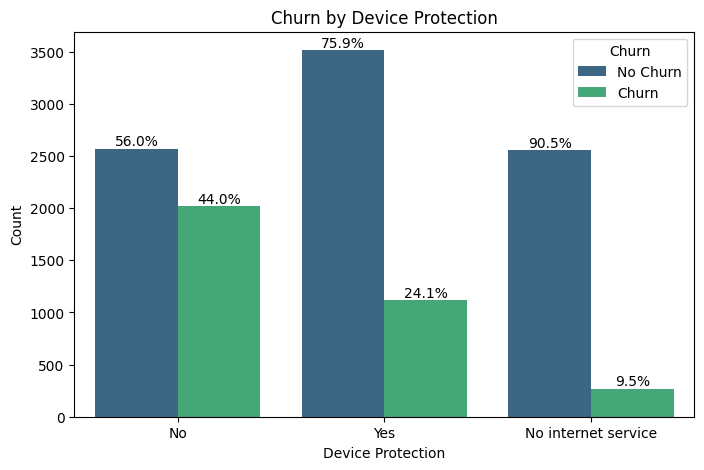

```python
plt.figure(figsize=(8, 5))
ax = sns.countplot(data=Data, x='DeviceProtection', hue='Churn', palette='viridis')
plt.title('Churn by Device Protection')
plt.xlabel('Device Protection')
plt.ylabel('Count')

# Pre-calculate churn percentages from the Data DataFrame
churn_percentages = Data.groupby('DeviceProtection')['Churn'].value_counts(normalize=True).unstack()

# Get the x-tick labels and their positions to map patch x-coordinates to category names
x_tick_positions = ax.get_xticks()
x_tick_labels = [label.get_text() for label in ax.get_xticklabels()]

# Assuming ax.containers[0] holds 'No Churn' bars and ax.containers[1] holds 'Churn' bars
if len(ax.containers) > 1:
    # Iterate over both containers (No Churn and Churn)
    for container_idx, container in enumerate(ax.containers):
        for patch in container:
            # Calculate the center x-coordinate of the bar
            bar_center_x = patch.get_x() + patch.get_width() / 2

            # Find the corresponding category label based on the x-coordinate
            # This requires finding the closest x-tick position
            closest_tick_idx = (np.abs(x_tick_positions - bar_center_x)).argmin()
            current_category = x_tick_labels[closest_tick_idx]

            # Get the correct percentage based on container_idx (0 for No Churn, 1 for Churn)
            if current_category in churn_percentages.index:
                percentage_val = churn_percentages.loc[current_category, container_idx] * 100
                ax.annotate(f'{percentage_val:.1f}%',
                            (patch.get_x() + patch.get_width() / 2., patch.get_height()),
                            ha='center', va='bottom', fontsize=10)

plt.legend(title='Churn', labels=['No Churn', 'Churn'])
plt.show()
```

- Customers without 'Device Protection' have a significantly higher churn rate of approximately 44%.
- Customers with 'Device Protection' have a much lower churn rate of about 24.1%.
- Customers with 'No internet service' have the lowest churn rate at approximately 9.5%.

This indicates that providing device protection services might contribute to customer retention, as customers without it are more likely to churn.

**12. Churn by TechSupport**

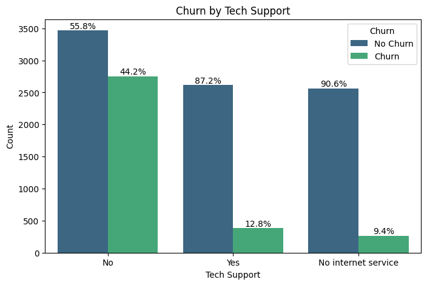

```python
plt.figure(figsize=(8, 5))
ax = sns.countplot(data=Data, x='TechSupport', hue='Churn', palette='viridis')
plt.title('Churn by Tech Support')
plt.xlabel('Tech Support')
plt.ylabel('Count')

# Pre-calculate churn percentages from the Data DataFrame
churn_percentages = Data.groupby('TechSupport')['Churn'].value_counts(normalize=True).unstack()

# Get the x-tick labels and their positions to map patch x-coordinates to category names
x_tick_positions = ax.get_xticks()
x_tick_labels = [label.get_text() for label in ax.get_xticklabels()]

# Assuming ax.containers[0] holds 'No Churn' bars and ax.containers[1] holds 'Churn' bars
if len(ax.containers) > 1:
    # Iterate over both containers (No Churn and Churn)
    for container_idx, container in enumerate(ax.containers):
        for patch in container:
            # Calculate the center x-coordinate of the bar
            bar_center_x = patch.get_x() + patch.get_width() / 2

            # Find the corresponding category label based on the x-coordinate
            # This requires finding the closest x-tick position
            closest_tick_idx = (np.abs(x_tick_positions - bar_center_x)).argmin()
            current_category = x_tick_labels[closest_tick_idx]

            # Get the correct percentage based on container_idx (0 for No Churn, 1 for Churn)
            if current_category in churn_percentages.index:
                percentage_val = churn_percentages.loc[current_category, container_idx] * 100
                ax.annotate(f'{percentage_val:.1f}%',
                            (patch.get_x() + patch.get_width() / 2., patch.get_height()),
                            ha='center', va='bottom', fontsize=10)

plt.legend(title='Churn', labels=['No Churn', 'Churn'])
plt.show()
```

- Customers with 'No Tech Support' have a significantly higher churn rate of approximately 44.2%.
- Customers with 'Yes Tech Support' have a much lower churn rate of about 12.8%.
- Customers with 'No internet service' have the lowest churn rate at approximately 9.4%.

This highlights the importance of technical support in customer retention, as customers without it are considerably more likely to churn.

**13. Churn by StreamingTV**

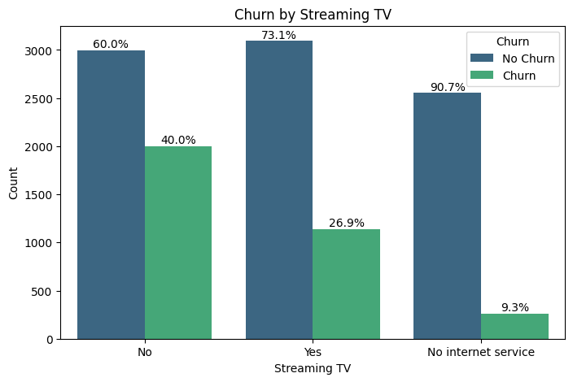

```python
plt.figure(figsize=(8, 5))
ax = sns.countplot(data=Data, x='StreamingTV', hue='Churn', palette='viridis')
plt.title('Churn by Streaming TV')
plt.xlabel('Streaming TV')
plt.ylabel('Count')

# Pre-calculate churn percentages from the Data DataFrame
churn_percentages = Data.groupby('StreamingTV')['Churn'].value_counts(normalize=True).unstack()

# Get the x-tick labels and their positions to map patch x-coordinates to category names
x_tick_positions = ax.get_xticks()
x_tick_labels = [label.get_text() for label in ax.get_xticklabels()]

# Assuming ax.containers[0] holds 'No Churn' bars and ax.containers[1] holds 'Churn' bars
if len(ax.containers) > 1:
    # Iterate over both containers (No Churn and Churn)
    for container_idx, container in enumerate(ax.containers):
        for patch in container:
            # Calculate the center x-coordinate of the bar
            bar_center_x = patch.get_x() + patch.get_width() / 2

            # Find the corresponding category label based on the x-coordinate
            # This requires finding the closest x-tick position
            closest_tick_idx = (np.abs(x_tick_positions - bar_center_x)).argmin()
            current_category = x_tick_labels[closest_tick_idx]

            # Get the correct percentage based on container_idx (0 for No Churn, 1 for Churn)
            if current_category in churn_percentages.index:
                percentage_val = churn_percentages.loc[current_category, container_idx] * 100
                ax.annotate(f'{percentage_val:.1f}%',
                            (patch.get_x() + patch.get_width() / 2., patch.get_height()),
                            ha='center', va='bottom', fontsize=10)

plt.legend(title='Churn', labels=['No Churn', 'Churn'])
plt.show()
```

This indicates that customers without streaming TV are somewhat more likely to churn than those with it.

**14. Churn by StreamingMovies**

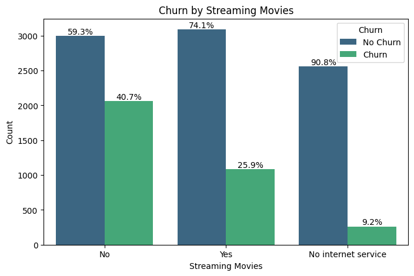

```python
plt.figure(figsize=(8, 5))
ax = sns.countplot(data=Data, x='StreamingMovies', hue='Churn', palette='viridis')
plt.title('Churn by Streaming Movies')
plt.xlabel('Streaming Movies')
plt.ylabel('Count')

# Pre-calculate churn percentages from the Data DataFrame
churn_percentages = Data.groupby('StreamingMovies')['Churn'].value_counts(normalize=True).unstack()

# Get the x-tick labels and their positions to map patch x-coordinates to category names
x_tick_positions = ax.get_xticks()
x_tick_labels = [label.get_text() for label in ax.get_xticklabels()]

# Assuming ax.containers[0] holds 'No Churn' bars and ax.containers[1] holds 'Churn' bars
if len(ax.containers) > 1:
    # Iterate over both containers (No Churn and Churn)
    for container_idx, container in enumerate(ax.containers):
        for patch in container:
            # Calculate the center x-coordinate of the bar
            bar_center_x = patch.get_x() + patch.get_width() / 2

            # Find the corresponding category label based on the x-coordinate
            # This requires finding the closest x-tick position
            closest_tick_idx = (np.abs(x_tick_positions - bar_center_x)).argmin()
            current_category = x_tick_labels[closest_tick_idx]

            # Get the correct percentage based on container_idx (0 for No Churn, 1 for Churn)
            if current_category in churn_percentages.index:
                percentage_val = churn_percentages.loc[current_category, container_idx] * 100
                ax.annotate(f'{percentage_val:.1f}%',
                            (patch.get_x() + patch.get_width() / 2., patch.get_height()),
                            ha='center', va='bottom', fontsize=10)

plt.legend(title='Churn', labels=['No Churn', 'Churn'])
plt.show()
```

Similar to Streaming TV, customers without streaming movie services are somewhat more likely to churn.

**15. Churn by Contract**

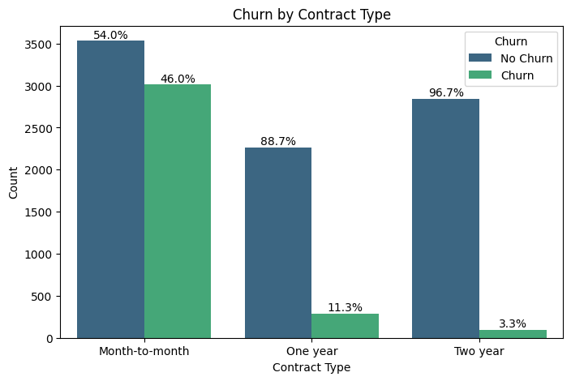

```python
plt.figure(figsize=(8, 5))
ax = sns.countplot(data=Data, x='Contract', hue='Churn', palette='viridis')
plt.title('Churn by Contract Type')
plt.xlabel('Contract Type')
plt.ylabel('Count')

# Pre-calculate churn percentages from the Data DataFrame
churn_percentages = Data.groupby('Contract')['Churn'].value_counts(normalize=True).unstack()

# Get the x-tick labels and their positions to map patch x-coordinates to category names
x_tick_positions = ax.get_xticks()
x_tick_labels = [label.get_text() for label in ax.get_xticklabels()]

# Assuming ax.containers[0] holds 'No Churn' bars and ax.containers[1] holds 'Churn' bars
if len(ax.containers) > 1:
    # Iterate over both containers (No Churn and Churn)
    for container_idx, container in enumerate(ax.containers):
        for patch in container:
            # Calculate the center x-coordinate of the bar
            bar_center_x = patch.get_x() + patch.get_width() / 2

            # Find the corresponding category label based on the x-coordinate
            # This requires finding the closest x-tick position
            closest_tick_idx = (np.abs(x_tick_positions - bar_center_x)).argmin()
            current_category = x_tick_labels[closest_tick_idx]

            # Get the correct percentage based on container_idx (0 for No Churn, 1 for Churn)
            if current_category in churn_percentages.index:
                percentage_val = churn_percentages.loc[current_category, container_idx] * 100
                ax.annotate(f'{percentage_val:.1f}%',
                            (patch.get_x() + patch.get_width() / 2., patch.get_height()),
                            ha='center', va='bottom', fontsize=10)

plt.legend(title='Churn', labels=['No Churn', 'Churn'])
plt.show()
```

- Month-to-month contracts have the highest churn rate, with approximately 46.0%.
- One year contracts show a much lower churn rate of about 11.3%.
- Two year contracts have the lowest churn rate at approximately 3.3%.

This analysis highlights that contract duration is a critical factor influencing customer churn, with longer contracts leading to higher retention.

**16. Churn by PaperlessBilling**

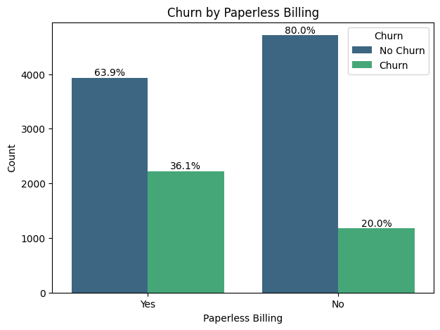

```python
plt.figure(figsize=(7, 5))
ax = sns.countplot(data=Data, x='PaperlessBilling', hue='Churn', palette='viridis')
plt.title('Churn by Paperless Billing')
plt.xlabel('Paperless Billing')
plt.ylabel('Count')

# Pre-calculate churn percentages from the Data DataFrame
churn_percentages = Data.groupby('PaperlessBilling')['Churn'].value_counts(normalize=True).unstack()

# Get the x-tick labels and their positions to map patch x-coordinates to category names
x_tick_positions = ax.get_xticks()
x_tick_labels = [label.get_text() for label in ax.get_xticklabels()]

# Assuming ax.containers[0] holds 'No Churn' bars and ax.containers[1] holds 'Churn' bars
if len(ax.containers) > 1:
    # Iterate over both containers (No Churn and Churn)
    for container_idx, container in enumerate(ax.containers):
        for patch in container:
            # Calculate the center x-coordinate of the bar
            bar_center_x = patch.get_x() + patch.get_width() / 2

            # Find the corresponding category label based on the x-coordinate
            # This requires finding the closest x-tick position
            closest_tick_idx = (np.abs(x_tick_positions - bar_center_x)).argmin()
            current_category = x_tick_labels[closest_tick_idx]

            # Get the correct percentage based on container_idx (0 for No Churn, 1 for Churn)
            if current_category in churn_percentages.index:
                percentage_val = churn_percentages.loc[current_category, container_idx] * 100
                ax.annotate(f'{percentage_val:.1f}%',
                            (patch.get_x() + patch.get_width() / 2., patch.get_height()),
                            ha='center', va='bottom', fontsize=10)

plt.legend(title='Churn', labels=['No Churn', 'Churn'])
plt.show()
```

- Customers who opted for Paperless Billing (Yes) have a significantly higher churn rate of approximately 36.1%.
- Customers who did not opt for Paperless Billing (No) have a much lower churn rate of approximately 20.0%.

This suggests that paperless billing might be correlated with higher churn, or it could be a characteristic of a customer segment more prone to churn.

**17. Churn by PaymentMethod**

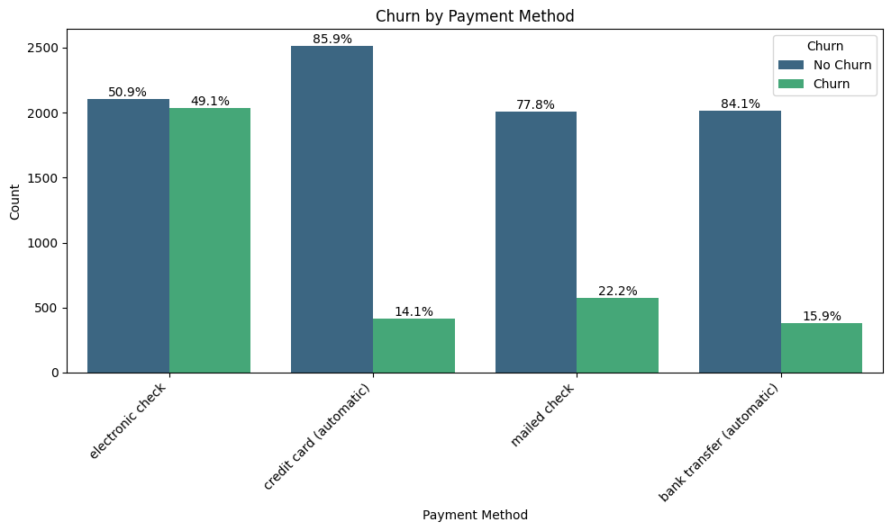

```python
plt.figure(figsize=(10, 6))
ax = sns.countplot(data=Data, x='PaymentMethod', hue='Churn', palette='viridis', order=Data['PaymentMethod'].value_counts().index)
plt.title('Churn by Payment Method')
plt.xlabel('Payment Method')
plt.ylabel('Count')

# Pre-calculate churn percentages from the Data DataFrame
churn_percentages = Data.groupby('PaymentMethod')['Churn'].value_counts(normalize=True).unstack()

# Get the x-tick labels and their positions to map patch x-coordinates to category names
x_tick_positions = ax.get_xticks()
x_tick_labels = [label.get_text() for label in ax.get_xticklabels()]

# Assuming ax.containers[0] holds 'No Churn' bars and ax.containers[1] holds 'Churn' bars
if len(ax.containers) > 1:
    # Iterate over both containers (No Churn and Churn)
    for container_idx, container in enumerate(ax.containers):
        for patch in container:
            # Calculate the center x-coordinate of the bar
            bar_center_x = patch.get_x() + patch.get_width() / 2

            # Find the corresponding category label based on the x-coordinate
            # This requires finding the closest x-tick position
            closest_tick_idx = (np.abs(x_tick_positions - bar_center_x)).argmin()
            current_category = x_tick_labels[closest_tick_idx]

            # Get the correct percentage based on container_idx (0 for No Churn, 1 for Churn)
            if current_category in churn_percentages.index:
                percentage_val = churn_percentages.loc[current_category, container_idx] * 100
                ax.annotate(f'{percentage_val:.1f}%',
                            (patch.get_x() + patch.get_width() / 2., patch.get_height()),
                            ha='center', va='bottom', fontsize=10)

plt.xticks(rotation=45, ha='right')
plt.tight_layout()
plt.legend(title='Churn', labels=['No Churn', 'Churn'])
plt.show()
```

- Electronic check is associated with the highest churn rate, approximately 49.1%.
- Mailed check has a churn rate of about 22.2%.
- Bank transfer (automatic) has a churn rate of about 15.9%.
- Credit card (automatic) has the lowest churn rate, approximately 14.1%.

This analysis suggests that manual payment methods, especially electronic checks, are strongly correlated with higher churn, while automatic payment methods like bank transfers and credit cards are associated with greater customer retention.

**18. Churn by MonthlyCharges**

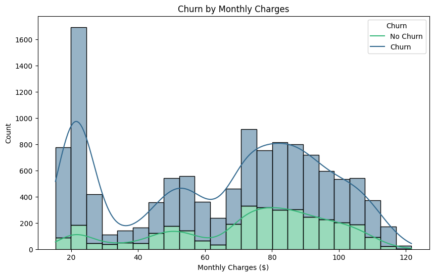

```python
plt.figure(figsize=(10, 6))
sns.histplot(data=Data, x='MonthlyCharges', hue='Churn', multiple='stack', palette='viridis', kde=True)
plt.title('Churn by Monthly Charges')
plt.xlabel('Monthly Charges ($)')
plt.ylabel('Count')
plt.legend(title='Churn', labels=['No Churn', 'Churn'])
plt.show()
```

**19. Churn by TotalCharges**

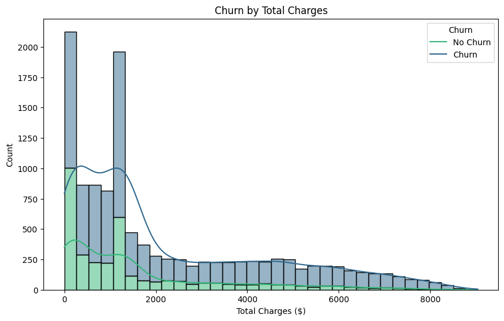

```python
plt.figure(figsize=(10, 6))
sns.histplot(data=Data, x='TotalCharges', hue='Churn', multiple='stack', palette='viridis', kde=True)
plt.title('Churn by Total Charges')
plt.xlabel('Total Charges ($)')
plt.ylabel('Count')
plt.legend(title='Churn', labels=['No Churn', 'Churn'])
plt.show()
```

- The plot shows that customers with lower total charges have a higher propensity to churn. As total charges increase, the proportion of churned customers decreases, indicating that customers with higher cumulative spending are more loyal.

### **Multi-Variate Analysis**

**1. Heatmap of Numerical Features**

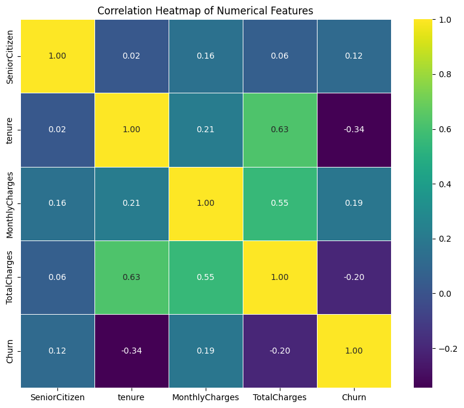

```python
plt.figure(figsize=(10, 8))
sns.heatmap(Data.select_dtypes(include=np.number).corr(), annot=True, cmap='viridis', fmt='.2f', linewidths=.5)
plt.title('Correlation Heatmap of Numerical Features')
plt.show()
```

From the correlation heatmap, we can observe the following:

- **Tenure and TotalCharges:** There is a strong positive correlation (0.63) between 'tenure' and 'TotalCharges'. This is expected, as customers with longer tenure are likely to accumulate higher total charges.
- **MonthlyCharges and TotalCharges:** There is a strong positive correlation (0.55) between 'MonthlyCharges' and 'TotalCharges'. This also makes sense, as higher monthly charges contribute to higher total charges over time.
- **MonthlyCharges and Churn:** There is a moderate positive correlation (0.19) between 'MonthlyCharges' and 'Churn'. This suggests that customers with higher monthly charges are slightly more likely to churn, which aligns with the bivariate analysis insights.
- **Tenure and Churn:** There is a moderate negative correlation (-0.34) between 'tenure' and 'Churn'. This indicates that customers with longer tenure are less likely to churn.
- **SeniorCitizen and Churn:** There is a weak positive correlation (0.12) between 'SeniorCitizen' and 'Churn'. This suggests that senior citizens are slightly more likely to churn, consistent with the earlier bivariate analysis.

Other correlations among numerical features are relatively weak, indicating that these variables largely have independent effects on churn or other numerical variables.

**2. Pair Plot of Numerical Features**

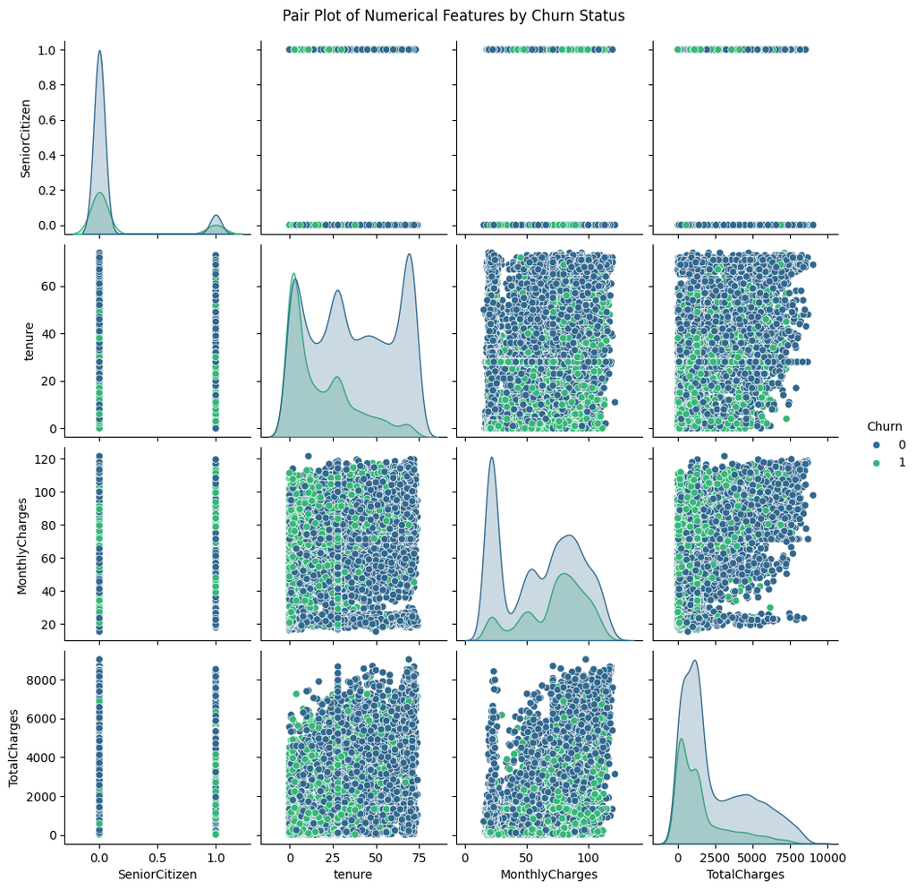

```python
numerical_cols_for_pairplot = Data.select_dtypes(include=np.number).columns.tolist()
# Remove 'Churn' from the list of numerical columns that will be plotted as x/y variables
if 'Churn' in numerical_cols_for_pairplot:
    numerical_cols_for_pairplot.remove('Churn')

# Now, create the pairplot. The `vars` argument specifies which columns to use for the grid axes.
# The `hue` argument specifies the column to color by.
sns.pairplot(Data, vars=numerical_cols_for_pairplot, hue='Churn', palette='viridis', diag_kind='kde')
plt.suptitle('Pair Plot of Numerical Features by Churn Status', y=1.02)
plt.show()
```

This pair plot provides a comprehensive view of the relationships between all numerical features ('SeniorCitizen', 'tenure', 'MonthlyCharges', 'TotalCharges') and their distributions, with the 'Churn' status highlighted. Key observations include:

- **Diagonal plots:** Show the distribution of each numerical feature for churned and non-churned customers. For instance, 'tenure' and 'TotalCharges' clearly show that non-churned customers tend to have higher values, while 'MonthlyCharges' indicates a more complex relationship.

### **Outlier Detection using Box Plots**

**1. Box Plot for SeniorCitizen**

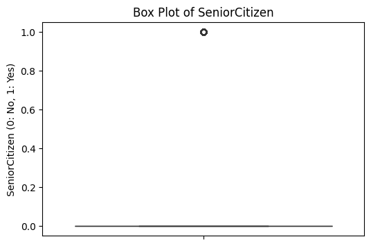

```python
plt.figure(figsize=(6, 4))
sns.boxplot(y=Data['SeniorCitizen'], palette='viridis')
plt.title('Box Plot of SeniorCitizen')
plt.ylabel('SeniorCitizen (0: No, 1: Yes)')
plt.show()
```

This box plot for 'SeniorCitizen' confirms its binary nature (0 or 1). There are no outliers in the traditional sense, as all values fall within the expected range for a binary variable.

**2. Box Plot for Tenure**

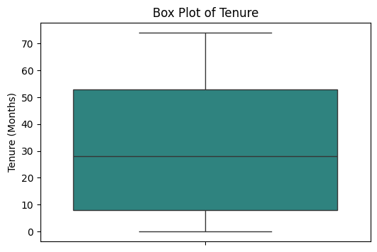

```python
plt.figure(figsize=(6, 4))
sns.boxplot(y=Data['tenure'], palette='viridis')
plt.title('Box Plot of Tenure')
plt.ylabel('Tenure (Months)')
plt.show()
```

The box plot for 'tenure' shows the distribution of customer tenure in months. While there might be some data points at the very low end, these represent new customers and are not considered erroneous outliers.

**3. Box Plot for MonthlyCharges**

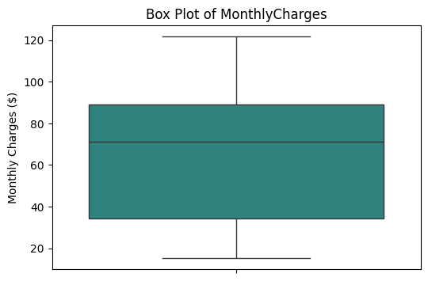

```python
plt.figure(figsize=(6, 4))
sns.boxplot(y=Data['MonthlyCharges'], palette='viridis')
plt.title('Box Plot of MonthlyCharges')
plt.ylabel('Monthly Charges ($)')
plt.show()
```

The box plot for 'MonthlyCharges' shows a relatively spread-out distribution. But there are not any potential outliers.

**4. Box Plot for TotalCharges**

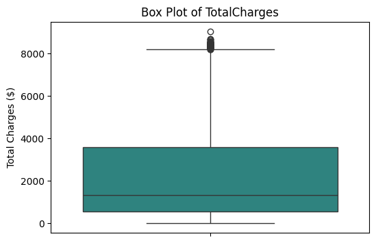

```python
plt.figure(figsize=(6, 4))
sns.boxplot(y=Data['TotalCharges'], palette='viridis')
plt.title('Box Plot of TotalCharges')
plt.ylabel('Total Charges ($)')
plt.show()
```

The box plot for 'TotalCharges' displays a right-skewed distribution with a notable number of data points extending far above the upper whisker. These indicate customers with very high cumulative charges, which is expected for long-term customers with high monthly bills. These are considered valid data points and not outliers to be removed, as they provide valuable information about high-value customers.

**5. Box Plot for Churn**

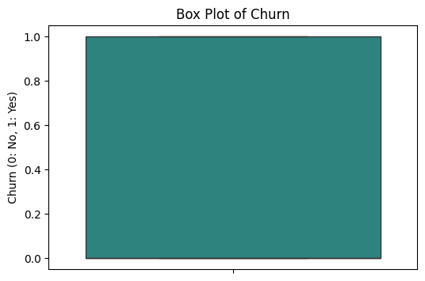

```python
plt.figure(figsize=(6, 4))
sns.boxplot(y=Data['Churn'], palette='viridis')
plt.title('Box Plot of Churn')
plt.ylabel('Churn (0: No, 1: Yes)')
plt.show()
```

The box plot for 'Churn' simply reflects its binary nature (0 or 1).

# **Exploring New Features**

### **1. TenureGroup**

The univariate analysis of 'tenure' showed bimaodal distribution. Creating a categorical 'tenure_group' can provide a clearer understanding of how customer loyalty influences churn. We will categorize 'tenure' into bins such as '0-12 Months', '13-24 Months', etc.

```python
# Define bins for tenure groups
bins = [-1, 12, 24, 36, 48, 60, Data['tenure'].max()]
labels = ['0-12 Months', '13-24 Months', '25-36 Months', '37-48 Months', '49-60 Months', '> 60 Months']

# Create the new 'TenureGroup' feature
Data['TenureGroup'] = pd.cut(Data['tenure'], bins=bins, labels=labels, right=True)

print("New feature 'TenureGroup' created successfully.")
display(Data[['tenure', 'TenureGroup']].head())
```

```
New feature 'TenureGroup' created successfully.
```

|  | tenure | TenureGroup |
| --- | --- | --- |
| 0 | 1.0 | 0-12 Months |
| 1 | 34.0 | 25-36 Months |
| 2 | 2.0 | 0-12 Months |
| 3 | 45.0 | 37-48 Months |
| 4 | 2.0 | 0-12 Months |

#### **1. Distribution of 'TenureGroup'**

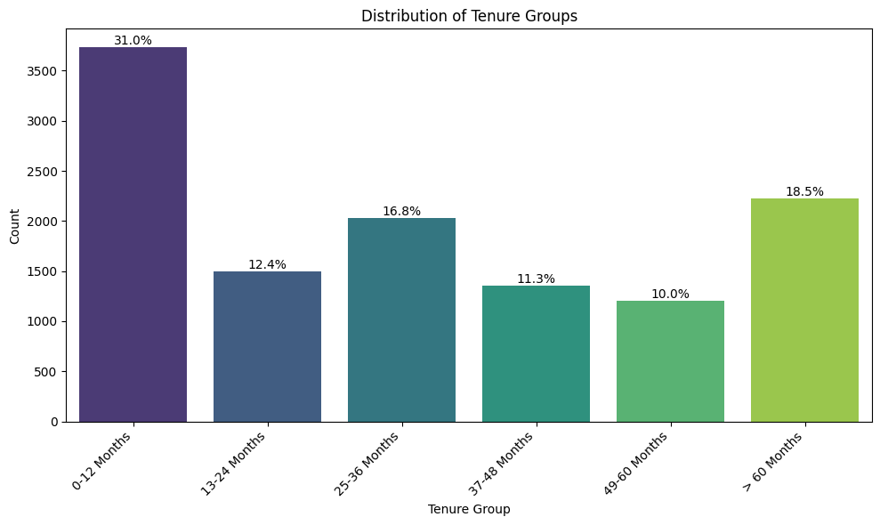

```python
plt.figure(figsize=(10, 6))
ax = sns.countplot(data=Data, x='TenureGroup', palette='viridis', order=labels)
plt.title('Distribution of Tenure Groups')
plt.xlabel('Tenure Group')
plt.ylabel('Count')

total = len(Data['TenureGroup'])
for p in ax.patches:
    percentage = '{:.1f}%'.format(100 * p.get_height()/total)
    x = p.get_x() + p.get_width() / 2
    y = p.get_height()
    ax.annotate(percentage, (x, y), ha='center', va='bottom')

plt.xticks(rotation=45, ha='right')
plt.tight_layout()
plt.show()
```

- The distribution of 'TenureGroup' shows that a large proportion of customers are in the '0-12 Months' group, indicating a significant number of new customers. There's also a substantial portion in the '> 60 Months' group, suggesting a loyal customer base. The middle tenure groups have fewer customers.

#### **2. Churn by 'TenureGroup'**

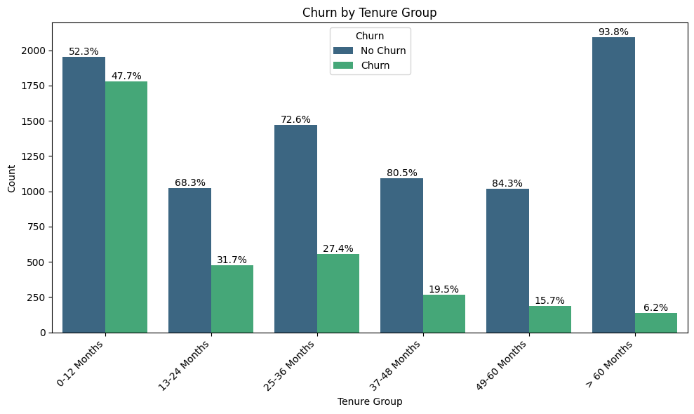

```python
plt.figure(figsize=(10, 6))
ax = sns.countplot(data=Data, x='TenureGroup', hue='Churn', palette='viridis', order=labels)
plt.title('Churn by Tenure Group')
plt.xlabel('Tenure Group')
plt.ylabel('Count')

# Pre-calculate churn percentages from the Data DataFrame
churn_percentages = Data.groupby('TenureGroup')['Churn'].value_counts(normalize=True).unstack()

# Get the x-tick labels and their positions to map patch x-coordinates to category names
x_tick_positions = ax.get_xticks()
x_tick_labels = [label.get_text() for label in ax.get_xticklabels()]

# Assuming ax.containers[0] holds 'No Churn' bars and ax.containers[1] holds 'Churn' bars
if len(ax.containers) > 1:
    # Iterate over both containers (No Churn and Churn)
    for container_idx, container in enumerate(ax.containers):
        for patch in container:
            # Calculate the center x-coordinate of the bar
            bar_center_x = patch.get_x() + patch.get_width() / 2

            # Find the corresponding category label based on the x-coordinate
            # This requires finding the closest x-tick position
            closest_tick_idx = (np.abs(x_tick_positions - bar_center_x)).argmin()
            current_category = x_tick_labels[closest_tick_idx]

            # Get the correct percentage based on container_idx (0 for No Churn, 1 for Churn)
            if current_category in churn_percentages.index:
                percentage_val = churn_percentages.loc[current_category, container_idx] * 100
                ax.annotate(f'{percentage_val:.1f}%',
                            (patch.get_x() + patch.get_width() / 2., patch.get_height()),
                            ha='center', va='bottom', fontsize=10)

plt.xticks(rotation=45, ha='right')
plt.tight_layout()
plt.legend(title='Churn', labels=['No Churn', 'Churn'])
plt.show()
```

- **'0-12 Months' Group:** This group has the highest churn rate, significantly higher than all other tenure groups.
- **Higher Tenure Groups:** The churn rate generally decreases as tenure increases. Customers in the '> 60 Months' group have the lowest churn rate, indicating strong loyalty.

### **2. HasInternet**

This feature will be a binary indicator, '1' if the customer has any internet service (DSL or Fiber optic) and '0' if they do not.

```python
Data['HasInternet'] = Data['InternetService'].apply(lambda x: 1 if x != 'No' else 0)
print("New feature 'HasInternet' created successfully.")
display(Data[['InternetService', 'HasInternet']].head())
```

```
New feature 'HasInternet' created successfully.
```

|  | InternetService | HasInternet |
| --- | --- | --- |
| 0 | DSL | 1 |
| 1 | DSL | 1 |
| 2 | DSL | 1 |
| 3 | DSL | 1 |
| 4 | Fiber optic | 1 |

#### **1. Distribution of 'HasInternet'**

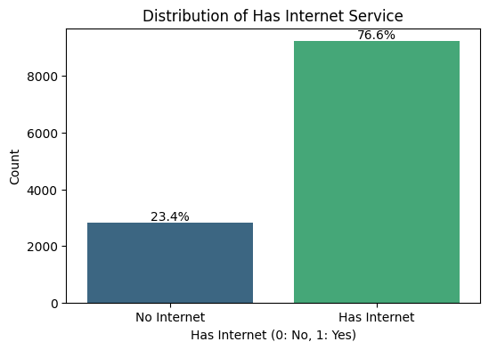

```python
plt.figure(figsize=(6, 4))
ax = sns.countplot(data=Data, x='HasInternet', palette='viridis')
plt.title('Distribution of Has Internet Service')
plt.xlabel('Has Internet (0: No, 1: Yes)')
plt.ylabel('Count')
plt.xticks(ticks=[0, 1], labels=['No Internet', 'Has Internet'])

total = len(Data['HasInternet'])
for p in ax.patches:
    percentage = '{:.1f}%'.format(100 * p.get_height()/total)
    x = p.get_x() + p.get_width() / 2
    y = p.get_height()
    ax.annotate(percentage, (x, y), ha='center', va='bottom')

plt.show()
```

- The majority of customers (76.6%) have internet service, while 23.4% do not.

#### **2. Churn by 'HasInternet'**

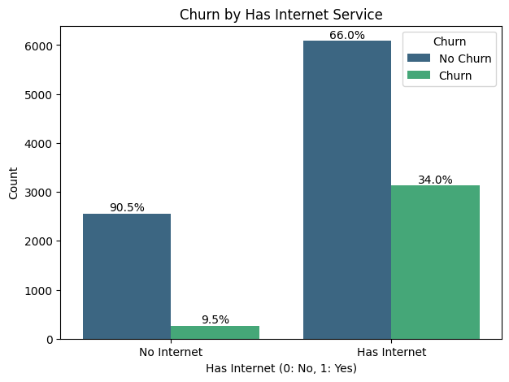

```python
plt.figure(figsize=(7, 5))
ax = sns.countplot(data=Data, x='HasInternet', hue='Churn', palette='viridis')
plt.title('Churn by Has Internet Service')
plt.xlabel('Has Internet (0: No, 1: Yes)')
plt.ylabel('Count')
plt.xticks(ticks=[0, 1], labels=['No Internet', 'Has Internet'])

# Pre-calculate churn percentages from the Data DataFrame
churn_percentages = Data.groupby('HasInternet')['Churn'].value_counts(normalize=True).unstack()

# Get the x-tick labels and their positions to map patch x-coordinates to category names
x_tick_positions = ax.get_xticks()
x_tick_labels = [label.get_text() for label in ax.get_xticklabels()]

# Assuming ax.containers[0] holds 'No Churn' bars and ax.containers[1] holds 'Churn' bars
if len(ax.containers) > 1:
    # Iterate over both containers (No Churn and Churn)
    for container_idx, container in enumerate(ax.containers):
        for patch in container:
            # Calculate the center x-coordinate of the bar
            bar_center_x = patch.get_x() + patch.get_width() / 2

            # Find the corresponding category label based on the x-coordinate
            # This requires finding the closest x-tick position
            closest_tick_idx = (np.abs(x_tick_positions - bar_center_x)).argmin()
            current_category_label = x_tick_labels[closest_tick_idx]

            # Convert current_category_label string label back to numerical key for indexing churn_percentages
            if current_category_label == 'No Internet':
                category_key = 0
            elif current_category_label == 'Has Internet':
                category_key = 1
            else:
                category_key = None # Fallback, should not happen with only two categories

            if category_key is not None and category_key in churn_percentages.index:
                percentage_val = churn_percentages.loc[category_key, container_idx] * 100
                ax.annotate(f'{percentage_val:.1f}%',
                            (patch.get_x() + patch.get_width() / 2., patch.get_height()),
                            ha='center', va='bottom', fontsize=10)

plt.legend(title='Churn', labels=['No Churn', 'Churn'])
plt.show()
```

- Customers who do not have internet service ('No Internet') have a very low churn rate of approximately 9.5%.
- Customers who do have internet service ('Has Internet') have a significantly higher churn rate of approximately 34.0%.

This confirms that having internet service is strongly associated with a higher likelihood of churn, likely due to the specific challenges or dissatisfaction with internet services (Like with Fiber Optic having high churn).

### **3. HasSecurity**

This feature will indicate whether a customer subscribes to any of the internet security related services like OnlineSecurity, OnlineBackup, DeviceProtection, or TechSupport.

```python
security_features = ['OnlineSecurity', 'OnlineBackup', 'DeviceProtection', 'TechSupport']
Data['HasSecurity'] = Data[security_features].apply(lambda x: 1 if any(s == 'Yes' for s in x) else 0, axis=1)
print("New feature 'HasSecurity' created successfully.")
display(Data[security_features + ['HasSecurity']].head())
```

```
New feature 'HasSecurity' created successfully.
```

|  | OnlineSecurity | OnlineBackup | DeviceProtection | TechSupport | HasSecurity |
| --- | --- | --- | --- | --- | --- |
| 0 | No | Yes | No | No | 1 |
| 1 | Yes | No | Yes | No | 1 |
| 2 | Yes | Yes | No | No | 1 |
| 3 | Yes | No | Yes | Yes | 1 |
| 4 | No | No | No | No | 0 |

#### **1. Distribution of 'HasSecurity'**

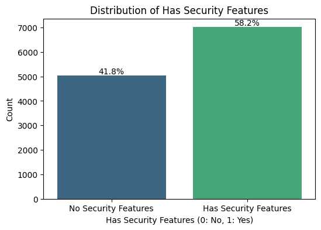

```python
plt.figure(figsize=(6, 4))
ax = sns.countplot(data=Data, x='HasSecurity', palette='viridis')
plt.title('Distribution of Has Security Features')
plt.xlabel('Has Security Features (0: No, 1: Yes)')
plt.ylabel('Count')
plt.xticks(ticks=[0, 1], labels=['No Security Features', 'Has Security Features'])

total = len(Data['HasSecurity'])
for p in ax.patches:
    percentage = '{:.1f}%'.format(100 * p.get_height()/total)
    x = p.get_x() + p.get_width() / 2
    y = p.get_height()
    ax.annotate(percentage, (x, y), ha='center', va='bottom')

plt.show()
```

- Approximately 41.80% of customers do not have any of these security-related features, while 58.2% have at least one.

#### **2. Churn by 'HasSecurity'**

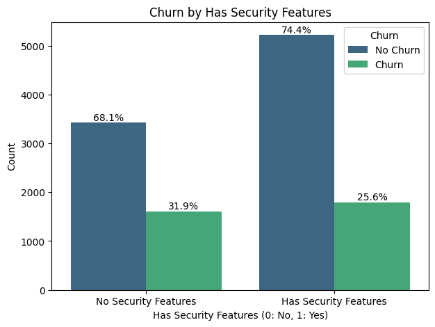

```python
plt.figure(figsize=(7, 5))
ax = sns.countplot(data=Data, x='HasSecurity', hue='Churn', palette='viridis')
plt.title('Churn by Has Security Features')
plt.xlabel('Has Security Features (0: No, 1: Yes)')
plt.ylabel('Count')
plt.xticks(ticks=[0, 1], labels=['No Security Features', 'Has Security Features'])

# Pre-calculate churn percentages from the Data DataFrame
churn_percentages = Data.groupby('HasSecurity')['Churn'].value_counts(normalize=True).unstack()

# Get the x-tick labels and their positions to map patch x-coordinates to category names
x_tick_positions = ax.get_xticks()
x_tick_labels = [label.get_text() for label in ax.get_xticklabels()]

# Assuming ax.containers[0] holds 'No Churn' bars and ax.containers[1] holds 'Churn' bars
if len(ax.containers) > 1:
    # Iterate over both containers (No Churn and Churn)
    for container_idx, container in enumerate(ax.containers):
        for patch in container:
            # Calculate the center x-coordinate of the bar
            bar_center_x = patch.get_x() + patch.get_width() / 2

            # Find the corresponding category label based on the x-coordinate
            # This requires finding the closest x-tick position
            closest_tick_idx = (np.abs(x_tick_positions - bar_center_x)).argmin()
            current_category_label = x_tick_labels[closest_tick_idx]

            # Convert current_category_label string label back to numerical key for indexing churn_percentages
            if current_category_label == 'No Security Features':
                category_key = 0
            elif current_category_label == 'Has Security Features':
                category_key = 1
            else:
                category_key = None # Fallback, should not happen with only two categories

            if category_key is not None and category_key in churn_percentages.index:
                percentage_val = churn_percentages.loc[category_key, container_idx] * 100
                ax.annotate(f'{percentage_val:.1f}%',
                            (patch.get_x() + patch.get_width() / 2., patch.get_height()),
                            ha='center', va='bottom', fontsize=10)

plt.legend(title='Churn', labels=['No Churn', 'Churn'])
plt.show()
```

- Customers who do not have any security features have a significantly higher churn rate of approximately 31.9%.
- Customers who have at least one security feature have lower churn rate of approximately 25.6%.

### **4.TotalServices**

This feature will represent the total number of services (phone, multiple lines, Internet, online security, online backup, device protection, tech support, streaming TV, streaming movies) which a customer subscribes.

```python
service_columns = [
    'PhoneService',
    'MultipleLines',
    'InternetService',
    'OnlineSecurity',
    'OnlineBackup',
    'DeviceProtection',
    'TechSupport',
    'StreamingTV',
    'StreamingMovies'
]

# Helper function to count 'Yes' or 'No' services
def count_active_services(row):
    count = 0
    if row['PhoneService'] == 'Yes':
        count += 1
    if row['MultipleLines'] == 'Yes':
        count += 1
    if row['InternetService'] != 'No': # DSL or Fiber optic
        count += 1
    # For the following, 'No internet service' implies 'No', so 'Yes' is the only positive indicator
    if row['OnlineSecurity'] == 'Yes':
        count += 1
    if row['OnlineBackup'] == 'Yes':
        count += 1
    if row['DeviceProtection'] == 'Yes':
        count += 1
    if row['TechSupport'] == 'Yes':
        count += 1
    if row['StreamingTV'] == 'Yes':
        count += 1
    if row['StreamingMovies'] == 'Yes':
        count += 1
    return count

Data['TotalServices'] = Data.apply(count_active_services, axis=1)
print("New feature 'TotalServices' created successfully.")
display(Data[service_columns + ['TotalServices']].head())
```

```
New feature 'TotalServices' created successfully.
```

|  | PhoneService | MultipleLines | InternetService | OnlineSecurity | OnlineBackup | DeviceProtection | TechSupport | StreamingTV | StreamingMovies | TotalServices |
| --- | --- | --- | --- | --- | --- | --- | --- | --- | --- | --- |
| 0 | No | No phone service | DSL | No | Yes | No | No | No | No | 2 |
| 1 | Yes | No | DSL | Yes | No | Yes | No | No | No | 4 |
| 2 | Yes | No | DSL | Yes | Yes | No | No | No | No | 4 |
| 3 | No | No phone service | DSL | Yes | No | Yes | Yes | No | No | 4 |
| 4 | Yes | No | Fiber optic | No | No | No | No | No | No | 2 |

#### **1. Distribution of 'TotalServices'**

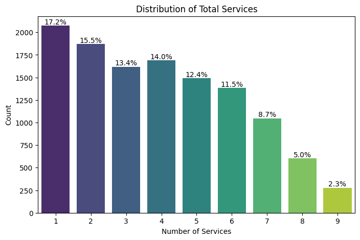

```python
plt.figure(figsize=(8, 5))
ax = sns.countplot(data=Data, x='TotalServices', palette='viridis')
plt.title('Distribution of Total Services')
plt.xlabel('Number of Services')
plt.ylabel('Count')

total = len(Data['TotalServices'])
for p in ax.patches:
    percentage = '{:.1f}%'.format(100 * p.get_height()/total)
    x = p.get_x() + p.get_width() / 2
    y = p.get_height()
    ax.annotate(percentage, (x, y), ha='center', va='bottom')

plt.show()
```

- The distribution shows that many customers have a low number of services (around 1-3), while there's also a considerable number of customers with a higher number of services (around 6-7). This indicates a diverse customer base in terms of service adoption.

#### **2. Churn by 'TotalServices'**

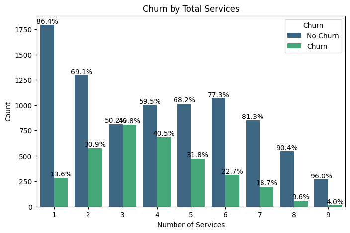

```python
plt.figure(figsize=(8, 5))
ax = sns.countplot(data=Data, x='TotalServices', hue='Churn', palette='viridis')
plt.title('Churn by Total Services')
plt.xlabel('Number of Services')
plt.ylabel('Count')

# Pre-calculate churn percentages from the Data DataFrame
churn_percentages = Data.groupby('TotalServices')['Churn'].value_counts(normalize=True).unstack()

# Get the x-tick labels and their positions to map patch x-coordinates to category names
x_tick_positions = ax.get_xticks()
x_tick_labels = [label.get_text() for label in ax.get_xticklabels()]

# Assuming ax.containers[0] holds 'No Churn' bars and ax.containers[1] holds 'Churn' bars
if len(ax.containers) > 1:
    # Iterate over both containers (No Churn and Churn)
    for container_idx, container in enumerate(ax.containers):
        for patch in container:
            # Calculate the center x-coordinate of the bar
            bar_center_x = patch.get_x() + patch.get_width() / 2

            # Find the corresponding category label based on the x-coordinate
            # This requires finding the closest x-tick position
            closest_tick_idx = (np.abs(x_tick_positions - bar_center_x)).argmin()
            current_category_label = x_tick_labels[closest_tick_idx]

            # Convert current_category_label string label back to numerical key for indexing churn_percentages
            category_key = int(current_category_label)

            if category_key in churn_percentages.index:
                percentage_val = churn_percentages.loc[category_key, container_idx] * 100
                ax.annotate(f'{percentage_val:.1f}%',
                            (patch.get_x() + patch.get_width() / 2., patch.get_height()),
                            ha='center', va='bottom', fontsize=10)

plt.legend(title='Churn', labels=['No Churn', 'Churn'])
plt.show()
```

This feature provides a nuanced view, suggesting that either very basic or very comprehensive service bundles might lead to higher retention, while a middle-ground offering might be more prone to churn.

# **Evaluation Metrics**

The target variable is binary (churn or no churn) and the dataset is imbalanced (fewer churned customers than non-churned), specific evaluation metrics are more appropriate than simple accuracy.

Here are the chosen metrics with their rationale:

1. **Recall for the 'Churn' class :**
   - **Rationale:** Recall measures the proportion of actual churners that were correctly identified by the model. (minimize False Negatives) Missing a churner means losing a customer, which directly impacts revenue.
2. **Precision for the 'Churn' class:**
   - **Rationale:** Precision measures the proportion of customers predicted as churners who actually churned.(minimize False Positives). High precision ensures that retention efforts are targeted effectively and resources are not wasted on customers who wouldn't churn anyway.
3. **F1-Score:**
   - **Rationale:** The F1-Score is the harmonic mean of Precision and Recall. A high F1-score indicates a good balance between identifying positive cases and not making too many false positive predictions.
4. **ROC AUC (Receiver Operating Characteristic - Area Under the Curve):**
   - **Rationale:** ROC AUC measures the ability of the model to distinguish between positive and negative classes across various classification thresholds. A higher AUC indicates a better model performance in separating churners from non-churners.

**In summary, while we will monitor accuracy, the primary focus will be on Recall, Precision, and F1-Score for the 'Churn' class, and ROC AUC for overall model performance, to ensure that the model is effective in identifying and acting upon potential customer churn.**

# **Building a Baseline Model (Logistic Regression)**

We will build a Logistic Regression model as our first baseline model.

### **Data Preprocessing**

```python
import numpy as np
import pandas as pd
from sklearn.model_selection import train_test_split
from sklearn.preprocessing import StandardScaler

# Separate features (X) and target (y)
X = Data.drop('Churn', axis=1)
y = Data['Churn']

# Identify categorical and numerical columns
categorical_cols = X.select_dtypes(include=['object', 'category']).columns
numerical_cols = X.select_dtypes(include=np.number).columns

# One-hot encode categorical features
X_encoded = pd.get_dummies(X, columns=categorical_cols, drop_first=True)

# Split the data into training+validation (85%) and testing (15%) sets
X_train_val, X_test, y_train_val, y_test = train_test_split(X_encoded, y, test_size=0.15, random_state=42, stratify=y)

# Split the training+validation data into training (70% of total) and validation (15% of total) sets
# test_size here is 0.15 / (1 - 0.15) = 0.15 / 0.85.
X_train, X_val, y_train, y_val = train_test_split(X_train_val, y_train_val, test_size=(0.15/(0.85)), random_state=42, stratify=y_train_val)

# Scale numerical features using StandardScaler
# Fit on training data only to prevent data leakage
scaler = StandardScaler()
X_train[numerical_cols] = scaler.fit_transform(X_train[numerical_cols])
X_val[numerical_cols] = scaler.transform(X_val[numerical_cols])
X_test[numerical_cols] = scaler.transform(X_test[numerical_cols])

print("Data preprocessing complete. Data split into training, validation, and testing sets, and features are scaled.")
print(f"X_train shape: {X_train.shape}")
print(f"X_val shape: {X_val.shape}")
print(f"X_test shape: {X_test.shape}")
print(f"y_train shape: {y_train.shape}")
print(f"y_val shape: {y_val.shape}")
print(f"y_test shape: {y_test.shape}")
```

```
Data preprocessing complete. Data split into training, validation, and testing sets, and features are scaled.
X_train shape: (8435, 38)
X_val shape: (1808, 38)
X_test shape: (1808, 38)
y_train shape: (8435,)
y_val shape: (1808,)
y_test shape: (1808,)
```

### **Training the Logistic Regression Model**

```python
from sklearn.linear_model import LogisticRegression

# Initialize and train the Logistic Regression model
log_reg = LogisticRegression(random_state=42, solver='liblinear')
log_reg.fit(X_train, y_train)

print("Logistic Regression model trained successfully.")
```

```
Logistic Regression model trained successfully.
```

```
Confusion Matrix (Logistic Regression - Validation Set):
```

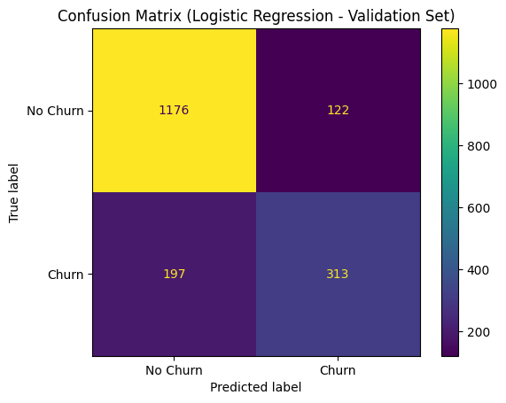

```
Classification Report (Logistic Regression - Validation Set):
              precision    recall  f1-score   support

    No Churn       0.86      0.91      0.88      1298
       Churn       0.72      0.61      0.66       510

    accuracy                           0.82      1808
   macro avg       0.79      0.76      0.77      1808
weighted avg       0.82      0.82      0.82      1808


ROC AUC Score (Logistic Regression - Validation Set): 0.8638
```

```python
from sklearn.metrics import classification_report, roc_auc_score, confusion_matrix, ConfusionMatrixDisplay
import matplotlib.pyplot as plt

# Make predictions on the validation set
y_pred_val_lr = log_reg.predict(X_val)
y_pred_proba_val_lr = log_reg.predict_proba(X_val)[:, 1]

# Confusion Matrix
print("\nConfusion Matrix (Logistic Regression - Validation Set):")
cm_val_lr = confusion_matrix(y_val, y_pred_val_lr)
cmd_val_lr = ConfusionMatrixDisplay(confusion_matrix=cm_val_lr, display_labels=['No Churn', 'Churn'])
cmd_val_lr.plot(cmap='viridis')
plt.title('Confusion Matrix (Logistic Regression - Validation Set)')
plt.show()

# Classification Report (Accuracy, Precision, Recall, F1-Score)
print("\nClassification Report (Logistic Regression - Validation Set):")
print(classification_report(y_val, y_pred_val_lr, target_names=['No Churn', 'Churn']))

# ROC AUC Score
roc_auc_val_lr = roc_auc_score(y_val, y_pred_proba_val_lr)
print(f"\nROC AUC Score (Logistic Regression - Validation Set): {roc_auc_val_lr:.4f}")
```

# **Decision Tree Classifier**

We will build Decision Tree model as our second baseline model.

```python
from sklearn.tree import DecisionTreeClassifier

# Initialize and train the Decision Tree Classifier model
dtc = DecisionTreeClassifier(random_state=42)
dtc.fit(X_train, y_train)

print("Decision Tree Classifier model trained successfully.")
```

```
Decision Tree Classifier model trained successfully.
```

### **Model Performance Evaluation (Decision Tree Classifier)**

```
Confusion Matrix (Decision Tree - Validation Set):
```

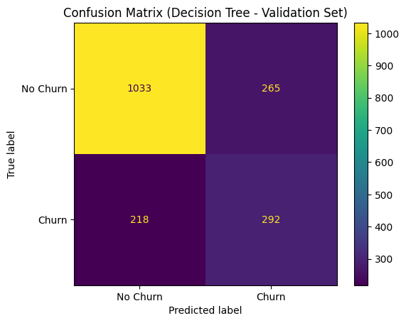

```
Classification Report (Decision Tree - Validation Set):
              precision    recall  f1-score   support

    No Churn       0.83      0.80      0.81      1298
       Churn       0.52      0.57      0.55       510

    accuracy                           0.73      1808
   macro avg       0.67      0.68      0.68      1808
weighted avg       0.74      0.73      0.74      1808


ROC AUC Score (Decision Tree - Validation Set): 0.6842
```

```python
from sklearn.metrics import classification_report, roc_auc_score, confusion_matrix, ConfusionMatrixDisplay

# Make predictions on the validation set
y_pred_dt = dtc.predict(X_val)
y_pred_proba_dt = dtc.predict_proba(X_val)[:, 1]

# Confusion Matrix
print("\nConfusion Matrix (Decision Tree - Validation Set):")
cm_dt = confusion_matrix(y_val, y_pred_dt)
cmd_dt = ConfusionMatrixDisplay(confusion_matrix=cm_dt, display_labels=['No Churn', 'Churn'])
cmd_dt.plot(cmap='viridis')
plt.title('Confusion Matrix (Decision Tree - Validation Set)')
plt.show()

# Classification Report (Accuracy, Precision, Recall, F1-Score)
print("\nClassification Report (Decision Tree - Validation Set):")
print(classification_report(y_val, y_pred_dt, target_names=['No Churn', 'Churn']))

# ROC AUC Score
roc_auc_dt = roc_auc_score(y_val, y_pred_proba_dt)
print(f"\nROC AUC Score (Decision Tree - Validation Set): {roc_auc_dt:.4f}")
```

# **K-Nearest Neighbors Classifier**

We will build K-Nearest Neighbors Classifier model as our third baseline model.

```python
from sklearn.neighbors import KNeighborsClassifier

# Initialize and train the KNN Classifier model
knn = KNeighborsClassifier(n_neighbors=5)
knn.fit(X_train, y_train)

print("K-Nearest Neighbors Classifier model trained successfully.")
```

```
K-Nearest Neighbors Classifier model trained successfully.
```

### **Model Performance Evaluation (K-Nearest Neighbors Classifier)**

```
Confusion Matrix (K-Nearest Neighbors - Validation Set):
```

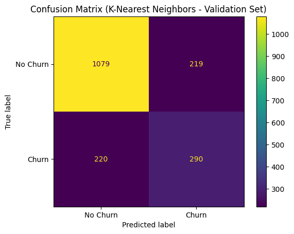

```
Classification Report (K-Nearest Neighbors - Validation Set):
              precision    recall  f1-score   support

    No Churn       0.83      0.83      0.83      1298
       Churn       0.57      0.57      0.57       510

    accuracy                           0.76      1808
   macro avg       0.70      0.70      0.70      1808
weighted avg       0.76      0.76      0.76      1808


ROC AUC Score (K-Nearest Neighbors - Validation Set): 0.7875
```

```python
from sklearn.metrics import classification_report, roc_auc_score, confusion_matrix, ConfusionMatrixDisplay

# Make predictions on the validation set
y_pred_knn = knn.predict(X_val)
y_pred_proba_knn = knn.predict_proba(X_val)[:, 1]

# Confusion Matrix
print("\nConfusion Matrix (K-Nearest Neighbors - Validation Set):")
cm_knn = confusion_matrix(y_val, y_pred_knn)
cmd_knn = ConfusionMatrixDisplay(confusion_matrix=cm_knn, display_labels=['No Churn', 'Churn'])
cmd_knn.plot(cmap='viridis')
plt.title('Confusion Matrix (K-Nearest Neighbors - Validation Set)')
plt.show()

# Classification Report (Accuracy, Precision, Recall, F1-Score)
print("\nClassification Report (K-Nearest Neighbors - Validation Set):")
print(classification_report(y_val, y_pred_knn, target_names=['No Churn', 'Churn']))

# ROC AUC Score
roc_auc_knn = roc_auc_score(y_val, y_pred_proba_knn)
print(f"\nROC AUC Score (K-Nearest Neighbors - Validation Set): {roc_auc_knn:.4f}")
```

# **Bagging Classifier**

We will build a Bagging Classifier model.

```python
from sklearn.ensemble import BaggingClassifier

# Initialize and train the Bagging Classifier model
bagging_clf = BaggingClassifier(random_state=42)
bagging_clf.fit(X_train, y_train)

print("Bagging Classifier model trained successfully.")
```

```
Bagging Classifier model trained successfully.
```

### **Model Performance Evaluation (Bagging Classifier)**

```
Confusion Matrix (Bagging Classifier - Validation Set):
```

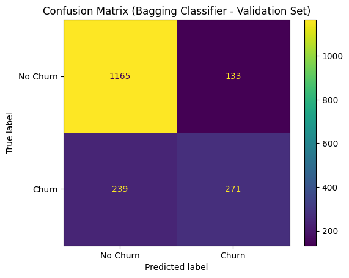

```
Classification Report (Bagging Classifier - Validation Set):
              precision    recall  f1-score   support

    No Churn       0.83      0.90      0.86      1298
       Churn       0.67      0.53      0.59       510

    accuracy                           0.79      1808
   macro avg       0.75      0.71      0.73      1808
weighted avg       0.78      0.79      0.79      1808


ROC AUC Score (Bagging Classifier - Validation Set): 0.8232
```

```python
from sklearn.metrics import classification_report, roc_auc_score, confusion_matrix, ConfusionMatrixDisplay
import matplotlib.pyplot as plt

# Make predictions on the validation set
y_pred_bagging = bagging_clf.predict(X_val)
y_pred_proba_bagging = bagging_clf.predict_proba(X_val)[:, 1]

# Confusion Matrix
print("\nConfusion Matrix (Bagging Classifier - Validation Set):")
cm_bagging = confusion_matrix(y_val, y_pred_bagging)
cmd_bagging = ConfusionMatrixDisplay(confusion_matrix=cm_bagging, display_labels=['No Churn', 'Churn'])
cmd_bagging.plot(cmap='viridis')
plt.title('Confusion Matrix (Bagging Classifier - Validation Set)')
plt.show()

# Classification Report (Accuracy, Precision, Recall, F1-Score)
print("\nClassification Report (Bagging Classifier - Validation Set):")
print(classification_report(y_val, y_pred_bagging, target_names=['No Churn', 'Churn']))

# ROC AUC Score
roc_auc_bagging = roc_auc_score(y_val, y_pred_proba_bagging)
print(f"\nROC AUC Score (Bagging Classifier - Validation Set): {roc_auc_bagging:.4f}")
```

# **Random Forest Classifier**

We will build a Random Forest Classifier model.

```python
from sklearn.ensemble import RandomForestClassifier

# Initialize and train the Random Forest Classifier model
rf_clf = RandomForestClassifier(random_state=42)
rf_clf.fit(X_train, y_train)

print("Random Forest Classifier model trained successfully.")
```

```
Random Forest Classifier model trained successfully.
```

### **Model Performance Evaluation (Random Forest Classifier)**

```
Confusion Matrix (Random Forest Classifier - Validation Set):
```

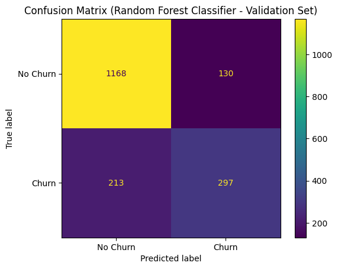

```
Classification Report (Random Forest Classifier - Validation Set):
              precision    recall  f1-score   support

    No Churn       0.85      0.90      0.87      1298
       Churn       0.70      0.58      0.63       510

    accuracy                           0.81      1808
   macro avg       0.77      0.74      0.75      1808
weighted avg       0.80      0.81      0.80      1808


ROC AUC Score (Random Forest Classifier - Validation Set): 0.8479
```

```python
from sklearn.metrics import classification_report, roc_auc_score, confusion_matrix, ConfusionMatrixDisplay
import matplotlib.pyplot as plt

# Make predictions on the validation set
y_pred_rf = rf_clf.predict(X_val)
y_pred_proba_rf = rf_clf.predict_proba(X_val)[:, 1]

# Confusion Matrix
print("\nConfusion Matrix (Random Forest Classifier - Validation Set):")
cm_rf = confusion_matrix(y_val, y_pred_rf)
cmd_rf = ConfusionMatrixDisplay(confusion_matrix=cm_rf, display_labels=['No Churn', 'Churn'])
cmd_rf.plot(cmap='viridis')
plt.title('Confusion Matrix (Random Forest Classifier - Validation Set)')
plt.show()

# Classification Report (Accuracy, Precision, Recall, F1-Score)
print("\nClassification Report (Random Forest Classifier - Validation Set):")
print(classification_report(y_val, y_pred_rf, target_names=['No Churn', 'Churn']))

# ROC AUC Score
roc_auc_rf = roc_auc_score(y_val, y_pred_proba_rf)
print(f"\nROC AUC Score (Random Forest Classifier - Validation Set): {roc_auc_rf:.4f}")
```

# **AdaBoost Classifier**

We will build an AdaBoost Classifier model.

```python
from sklearn.ensemble import AdaBoostClassifier

# Initialize and train the AdaBoost Classifier model
adaboost_clf = AdaBoostClassifier(random_state=42)
adaboost_clf.fit(X_train, y_train)

print("AdaBoost Classifier model trained successfully.")
```

```
AdaBoost Classifier model trained successfully.
```

### **Model Performance Evaluation (AdaBoost Classifier)**

```
Confusion Matrix (AdaBoost Classifier - Validation Set):
```

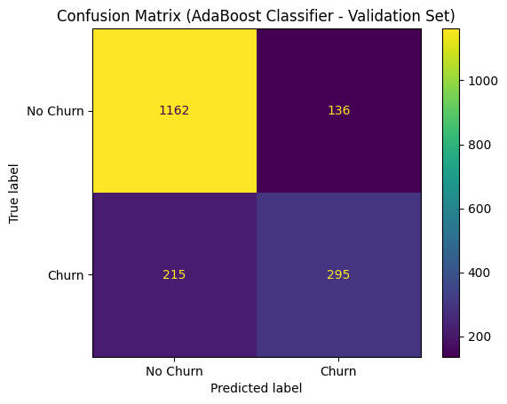

```
Classification Report (AdaBoost Classifier - Validation Set):
              precision    recall  f1-score   support

    No Churn       0.84      0.90      0.87      1298
       Churn       0.68      0.58      0.63       510

    accuracy                           0.81      1808
   macro avg       0.76      0.74      0.75      1808
weighted avg       0.80      0.81      0.80      1808


ROC AUC Score (AdaBoost Classifier - Validation Set): 0.8569
```

```python
from sklearn.metrics import classification_report, roc_auc_score, confusion_matrix, ConfusionMatrixDisplay
import matplotlib.pyplot as plt

# Make predictions on the validation set
y_pred_adaboost = adaboost_clf.predict(X_val)
y_pred_proba_adaboost = adaboost_clf.predict_proba(X_val)[:, 1]

# Confusion Matrix
print("\nConfusion Matrix (AdaBoost Classifier - Validation Set):")
cm_adaboost = confusion_matrix(y_val, y_pred_adaboost)
cmd_adaboost = ConfusionMatrixDisplay(confusion_matrix=cm_adaboost, display_labels=['No Churn', 'Churn'])
cmd_adaboost.plot(cmap='viridis')
plt.title('Confusion Matrix (AdaBoost Classifier - Validation Set)')
plt.show()

# Classification Report (Accuracy, Precision, Recall, F1-Score)
print("\nClassification Report (AdaBoost Classifier - Validation Set):")
print(classification_report(y_val, y_pred_adaboost, target_names=['No Churn', 'Churn']))

# ROC AUC Score
roc_auc_adaboost = roc_auc_score(y_val, y_pred_proba_adaboost)
print(f"\nROC AUC Score (AdaBoost Classifier - Validation Set): {roc_auc_adaboost:.4f}")
```

# **Gradient Boosting Classifier**

We will build a Gradient Boosting Classifier model.

```python
from sklearn.ensemble import GradientBoostingClassifier

# Initialize and train the Gradient Boosting Classifier model
gbc = GradientBoostingClassifier(random_state=42)
gbc.fit(X_train, y_train)

print("Gradient Boosting Classifier model trained successfully.")
```

```
Gradient Boosting Classifier model trained successfully.
```

### **Model Performance Evaluation (Gradient Boosting Classifier)**

```
Confusion Matrix (Gradient Boosting Classifier - Validation Set):
```

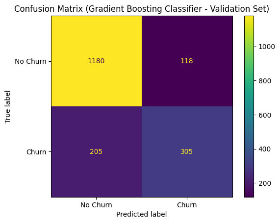

```
Classification Report (Gradient Boosting Classifier - Validation Set):
              precision    recall  f1-score   support

    No Churn       0.85      0.91      0.88      1298
       Churn       0.72      0.60      0.65       510

    accuracy                           0.82      1808
   macro avg       0.79      0.75      0.77      1808
weighted avg       0.82      0.82      0.82      1808


ROC AUC Score (Gradient Boosting Classifier - Validation Set): 0.8647
```

```python
from sklearn.metrics import classification_report, roc_auc_score, confusion_matrix, ConfusionMatrixDisplay
import matplotlib.pyplot as plt

# Make predictions on the validation set
y_pred_gbc = gbc.predict(X_val)
y_pred_proba_gbc = gbc.predict_proba(X_val)[:, 1]

# Confusion Matrix
print("\nConfusion Matrix (Gradient Boosting Classifier - Validation Set):")
cm_gbc = confusion_matrix(y_val, y_pred_gbc)
cmd_gbc = ConfusionMatrixDisplay(confusion_matrix=cm_gbc, display_labels=['No Churn', 'Churn'])
cmd_gbc.plot(cmap='viridis')
plt.title('Confusion Matrix (Gradient Boosting Classifier - Validation Set)')
plt.show()

# Classification Report (Accuracy, Precision, Recall, F1-Score)
print("\nClassification Report (Gradient Boosting Classifier - Validation Set):")
print(classification_report(y_val, y_pred_gbc, target_names=['No Churn', 'Churn']))

# ROC AUC Score
roc_auc_gbc = roc_auc_score(y_val, y_pred_proba_gbc)
print(f"\nROC AUC Score (Gradient Boosting Classifier - Validation Set): {roc_auc_gbc:.4f}")
```

# **XGBoost Classifier**

We will build an XGBoost Classifier model.

```python
from xgboost import XGBClassifier

# Initialize and train the XGBoost Classifier model
xgb_clf = XGBClassifier(random_state=42, use_label_encoder=False, eval_metric='logloss')
xgb_clf.fit(X_train, y_train)

print("XGBoost Classifier model trained successfully.")
```

```
XGBoost Classifier model trained successfully.
```

### **Model Performance Evaluation (XGBoost Classifier)**

```
Confusion Matrix (XGBoost Classifier - Validation Set):
```

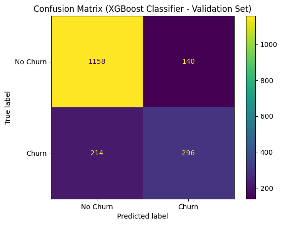

```
Classification Report (XGBoost Classifier - Validation Set):
              precision    recall  f1-score   support

    No Churn       0.84      0.89      0.87      1298
       Churn       0.68      0.58      0.63       510

    accuracy                           0.80      1808
   macro avg       0.76      0.74      0.75      1808
weighted avg       0.80      0.80      0.80      1808


ROC AUC Score (XGBoost Classifier - Validation Set): 0.8509
```

```python
from sklearn.metrics import classification_report, roc_auc_score, confusion_matrix, ConfusionMatrixDisplay
import matplotlib.pyplot as plt

# Make predictions on the validation set
y_pred_xgb = xgb_clf.predict(X_val)
y_pred_proba_xgb = xgb_clf.predict_proba(X_val)[:, 1]

# Confusion Matrix
print("\nConfusion Matrix (XGBoost Classifier - Validation Set):")
cm_xgb = confusion_matrix(y_val, y_pred_xgb)
cmd_xgb = ConfusionMatrixDisplay(confusion_matrix=cm_xgb, display_labels=['No Churn', 'Churn'])
cmd_xgb.plot(cmap='viridis')
plt.title('Confusion Matrix (XGBoost Classifier - Validation Set)')
plt.show()

# Classification Report (Accuracy, Precision, Recall, F1-Score)
print("\nClassification Report (XGBoost Classifier - Validation Set):")
print(classification_report(y_val, y_pred_xgb, target_names=['No Churn', 'Churn']))

# ROC AUC Score
roc_auc_xgb = roc_auc_score(y_val, y_pred_proba_xgb)
print(f"\nROC AUC Score (XGBoost Classifier - Validation Set): {roc_auc_xgb:.4f}")
```

# **Model Performance Comparison**

Let's compare the performance of all the models on the validation set using our chosen evaluation metrics.

```python
from sklearn.metrics import accuracy_score, precision_score, recall_score, f1_score, roc_auc_score

# Dictionary to store results for each model
results = {
    'Model': [],
    'Accuracy': [],
    'Precision (Churn)': [],
    'Recall (Churn)': [],
    'F1-Score (Churn)': [],
    'ROC AUC': []
}

def add_model_results(model_name, y_true, y_pred, y_proba):
    results['Model'].append(model_name)
    results['Accuracy'].append(accuracy_score(y_true, y_pred))
    results['Precision (Churn)'].append(precision_score(y_true, y_pred, pos_label=1))
    results['Recall (Churn)'].append(recall_score(y_true, y_pred, pos_label=1))
    results['F1-Score (Churn)'].append(f1_score(y_true, y_pred, pos_label=1))
    results['ROC AUC'].append(roc_auc_score(y_true, y_proba))

# Add results for Logistic Regression
add_model_results('Logistic Regression', y_val, y_pred_val_lr, y_pred_proba_val_lr)

# Add results for Decision Tree
add_model_results('Decision Tree', y_val, y_pred_dt, y_pred_proba_dt)

# Add results for K-Nearest Neighbors
add_model_results('K-Nearest Neighbors', y_val, y_pred_knn, y_pred_proba_knn)

# Add results for Bagging Classifier
add_model_results('Bagging Classifier', y_val, y_pred_bagging, y_pred_proba_bagging)

# Add results for Random Forest Classifier
add_model_results('Random Forest Classifier', y_val, y_pred_rf, y_pred_proba_rf)

# Add results for AdaBoost Classifier
add_model_results('AdaBoost Classifier', y_val, y_pred_adaboost, y_pred_proba_adaboost)

# Add results for Gradient Boosting Classifier
add_model_results('Gradient Boosting Classifier', y_val, y_pred_gbc, y_pred_proba_gbc)

# Add results for XGBoost Classifier
add_model_results('XGBoost Classifier', y_val, y_pred_xgb, y_pred_proba_xgb)

# Create DataFrame
results_df = pd.DataFrame(results)
results_df = results_df.round(4)

# Display the results table
display(results_df.sort_values(by='ROC AUC', ascending=False))
```

|  | Model | Accuracy | Precision (Churn) | Recall (Churn) | F1-Score (Churn) | ROC AUC |
| --- | --- | --- | --- | --- | --- | --- |
| 6 | Gradient Boosting Classifier | 0.8213 | 0.7210 | 0.5980 | 0.6538 | 0.8647 |
| 0 | Logistic Regression | 0.8236 | 0.7195 | 0.6137 | 0.6624 | 0.8638 |
| 5 | AdaBoost Classifier | 0.8059 | 0.6845 | 0.5784 | 0.6270 | 0.8569 |
| 7 | XGBoost Classifier | 0.8042 | 0.6789 | 0.5804 | 0.6258 | 0.8509 |
| 4 | Random Forest Classifier | 0.8103 | 0.6956 | 0.5824 | 0.6339 | 0.8479 |
| 3 | Bagging Classifier | 0.7942 | 0.6708 | 0.5314 | 0.5930 | 0.8232 |
| 2 | K-Nearest Neighbors | 0.7572 | 0.5697 | 0.5686 | 0.5692 | 0.7875 |
| 1 | Decision Tree | 0.7329 | 0.5242 | 0.5725 | 0.5473 | 0.6842 |

### **Observations**

Based on the evaluation metrics, particularly focusing on Recall (Churn), Precision (Churn), F1-Score (Churn), and ROC AUC, we can make the following observations:

- **Overall Best Performers:**
  - **Logistic Regression** and **Gradient Boosting Classifier** show the best overall performance with the highest ROC AUC scores (0.8638 and 0.8647 respectively). These models also exhibit a good balance across precision and recall for the churn class.
- **Recall (Churn):**
  - **Logistic Regression** (0.61) and **Gradient Boosting Classifier** (0.60), **AdaBoost Classifier** (0.58) and **XGBoost Classifier** (0.58), and **Random Forest Classifier** (0.58) achieve relatively good recall scores, meaning they are better at identifying actual churners. This is crucial for AlphaCom to proactively target at-risk customers.
- **Precision (Churn):**
  - **Logistic Regression** (0.72) and **Gradient Boosting Classifier** (0.72) demonstrate the highest precision for the churn class. This means that when these models predict a customer will churn, they are more likely to be correct, leading to more efficient resource allocation for retention campaigns.
  - **AdaBoost Classifier** (0.68), **XGBoost Classifier** (0.68), **Bagging Classifier** (0.67), and **Random Forest Classifier** (0.70) also show decent precision scores.
  - **Decision Tree** (0.52) and **K-Nearest Neighbors** (0.57) have the lowest precision, indicating a higher rate of false positives, which could lead to wasted retention efforts.
- **F1-Score (Churn):**
  - **Logistic Regression** (0.66) and **Gradient Boosting Classifier** (0.65) lead in F1-score, suggesting a strong balance between identifying churners and doing so accurately. This is a robust indicator for overall effectiveness in churn prediction.
- **ROC AUC:**
  - **Gradient Boosting Classifier** (0.8647) and **Logistic Regression** (0.8638) have the highest ROC AUC scores, indicating their superior ability to distinguish between churners and non-churners across various classification thresholds. This makes them highly reliable for ranking customers by their churn risk.

From these obervations we will choose **Gradient Boosting Classifier**, **Logistic Regression**, **AdaBoost Classifier**, **XGBoost Classifier** and **Random Forest Classifier** for tunning.

# **Hyperparameter Tuning for Gradient Boosting Classifier**

```python
from sklearn.ensemble import GradientBoostingClassifier
from sklearn.model_selection import GridSearchCV

# Define the parameter grid to search
param_grid = {
    'n_estimators': [50, 100, 200], # Number of boosting stages
    'learning_rate': [0.01, 0.1, 0.2], # Step size shrinkage
    'max_depth': [3, 5, 7] # Maximum depth of the individual regression estimators
}

# Initialize Gradient Boosting Classifier
gbc = GradientBoostingClassifier(random_state=42)

# Initialize GridSearchCV
grid_search_gbc = GridSearchCV(
    estimator=gbc,
    param_grid=param_grid,
    scoring='roc_auc', # Optimize for ROC AUC, as identified earlier
    cv=3, # Use 3-fold cross-validation
    n_jobs=-1, # Use all available cores
    verbose=2 # Display progress
)

# Fit GridSearchCV to the training data
grid_search_gbc.fit(X_train, y_train)

print("GridSearchCV for Gradient Boosting Classifier completed successfully.")
print(f"Best parameters found: {grid_search_gbc.best_params_}")
print(f"Best ROC AUC score: {grid_search_gbc.best_score_:.4f}")
```

```
Fitting 3 folds for each of 27 candidates, totalling 81 fits
GridSearchCV for Gradient Boosting Classifier completed successfully.
Best parameters found: {'learning_rate': 0.1, 'max_depth': 3, 'n_estimators': 50}
Best ROC AUC score: 0.8469
```

### **Evaluate Tuned Gradient Boosting Classifier**

```
Confusion Matrix (Tuned Gradient Boosting Classifier - Validation Set):
```

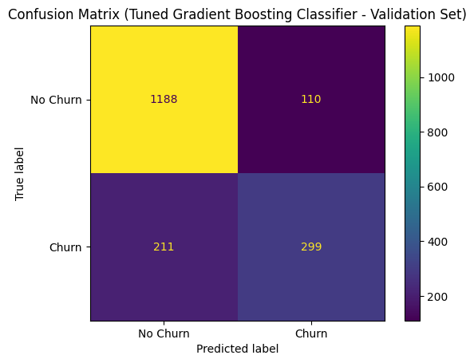

```
Classification Report (Tuned Gradient Boosting Classifier - Validation Set):
              precision    recall  f1-score   support

    No Churn       0.85      0.92      0.88      1298
       Churn       0.73      0.59      0.65       510

    accuracy                           0.82      1808
   macro avg       0.79      0.75      0.77      1808
weighted avg       0.82      0.82      0.82      1808


ROC AUC Score (Tuned Gradient Boosting Classifier - Validation Set): 0.8634
```

```python
from sklearn.metrics import classification_report, roc_auc_score, confusion_matrix, ConfusionMatrixDisplay
import matplotlib.pyplot as plt

# Get the best model from GridSearchCV
best_gbc = grid_search_gbc.best_estimator_

# Make predictions on the validation set using the best model
y_pred_gbc_tuned = best_gbc.predict(X_val)
y_pred_proba_gbc_tuned = best_gbc.predict_proba(X_val)[:, 1]

# Confusion Matrix
print("\nConfusion Matrix (Tuned Gradient Boosting Classifier - Validation Set):")
cm_gbc_tuned = confusion_matrix(y_val, y_pred_gbc_tuned)
cmd_gbc_tuned = ConfusionMatrixDisplay(confusion_matrix=cm_gbc_tuned, display_labels=['No Churn', 'Churn'])
cmd_gbc_tuned.plot(cmap='viridis')
plt.title('Confusion Matrix (Tuned Gradient Boosting Classifier - Validation Set)')
plt.show()

# Classification Report (Accuracy, Precision, Recall, F1-Score)
print("\nClassification Report (Tuned Gradient Boosting Classifier - Validation Set):")
print(classification_report(y_val, y_pred_gbc_tuned, target_names=['No Churn', 'Churn']))

# ROC AUC Score
roc_auc_gbc_tuned = roc_auc_score(y_val, y_pred_proba_gbc_tuned)
print(f"\nROC AUC Score (Tuned Gradient Boosting Classifier - Validation Set): {roc_auc_gbc_tuned:.4f}")
```

# **Hyperparameter Tuning for Logistic Regression**

```python
from sklearn.linear_model import LogisticRegression
from sklearn.model_selection import GridSearchCV

# Define the parameter grid to search
param_grid_lr = {
    'penalty': ['l1', 'l2'], # Regularization penalty
    'C': [0.001, 0.01, 0.1, 1, 10, 100], # Inverse of regularization strength
    'solver': ['liblinear'] # Solver that supports both l1 and l2 penalties
}

# Initialize Logistic Regression model
log_reg_tune = LogisticRegression(random_state=42)

# Initialize GridSearchCV
grid_search_lr = GridSearchCV(
    estimator=log_reg_tune,
    param_grid=param_grid_lr,
    scoring='roc_auc', # Optimize for ROC AUC
    cv=3, # Use 3-fold cross-validation
    n_jobs=-1, # Use all available cores
    verbose=2 # Display progress
)

# Fit GridSearchCV to the training data
grid_search_lr.fit(X_train, y_train)

print("GridSearchCV for Logistic Regression completed successfully.")
print(f"Best parameters found: {grid_search_lr.best_params_}")
print(f"Best ROC AUC score: {grid_search_lr.best_score_:.4f}")
```

```
Fitting 3 folds for each of 12 candidates, totalling 36 fits
GridSearchCV for Logistic Regression completed successfully.
Best parameters found: {'C': 0.1, 'penalty': 'l1', 'solver': 'liblinear'}
Best ROC AUC score: 0.8472
```

### **Evaluate Tuned Logistic Regression Classifier**

```
Confusion Matrix (Tuned Logistic Regression - Validation Set):
```

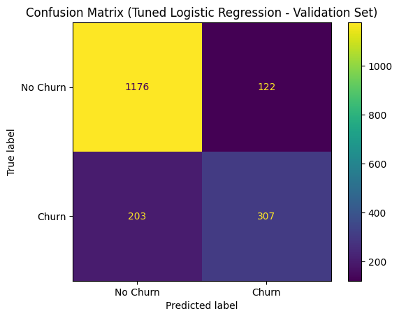

```
Classification Report (Tuned Logistic Regression - Validation Set):
              precision    recall  f1-score   support

    No Churn       0.85      0.91      0.88      1298
       Churn       0.72      0.60      0.65       510

    accuracy                           0.82      1808
   macro avg       0.78      0.75      0.77      1808
weighted avg       0.81      0.82      0.82      1808


ROC AUC Score (Tuned Logistic Regression - Validation Set): 0.8618
```

```python
from sklearn.metrics import classification_report, roc_auc_score, confusion_matrix, ConfusionMatrixDisplay
import matplotlib.pyplot as plt

# Get the best model from GridSearchCV
best_log_reg = grid_search_lr.best_estimator_

# Make predictions on the validation set using the best model
y_pred_lr_tuned = best_log_reg.predict(X_val)
y_pred_proba_lr_tuned = best_log_reg.predict_proba(X_val)[:, 1]

# Confusion Matrix
print("\nConfusion Matrix (Tuned Logistic Regression - Validation Set):")
cm_lr_tuned = confusion_matrix(y_val, y_pred_lr_tuned)
cmd_lr_tuned = ConfusionMatrixDisplay(confusion_matrix=cm_lr_tuned, display_labels=['No Churn', 'Churn'])
cmd_lr_tuned.plot(cmap='viridis')
plt.title('Confusion Matrix (Tuned Logistic Regression - Validation Set)')
plt.show()

# Classification Report (Accuracy, Precision, Recall, F1-Score)
print("\nClassification Report (Tuned Logistic Regression - Validation Set):")
print(classification_report(y_val, y_pred_lr_tuned, target_names=['No Churn', 'Churn']))

# ROC AUC Score
roc_auc_lr_tuned = roc_auc_score(y_val, y_pred_proba_lr_tuned)
print(f"\nROC AUC Score (Tuned Logistic Regression - Validation Set): {roc_auc_lr_tuned:.4f}")
```

# **Hyperparameter Tuning for AdaBoost Classifier**

```python
from sklearn.ensemble import AdaBoostClassifier
from sklearn.tree import DecisionTreeClassifier
from sklearn.model_selection import GridSearchCV

# Define the base estimator for AdaBoost. DecisionTree is commonly used.
base_estimator = DecisionTreeClassifier(random_state=42, max_depth=1) # Limiting max_depth for faster tuning and to prevent overfitting of base estimators

# Define the parameter grid to search
param_grid_adaboost = {
    'n_estimators': [50, 100, 200], # Number of boosting rounds
    'learning_rate': [0.01, 0.1, 1.0] # Step size shrinkage
}

# Initialize AdaBoost Classifier with the base estimator
adaboost_tune = AdaBoostClassifier(estimator=base_estimator, random_state=42)

# Initialize GridSearchCV
grid_search_adaboost = GridSearchCV(
    estimator=adaboost_tune,
    param_grid=param_grid_adaboost,
    scoring='roc_auc', # Optimize for ROC AUC
    cv=3, # Use 3-fold cross-validation
    n_jobs=-1, # Use all available cores
    verbose=2 # Display progress
)

# Fit GridSearchCV to the training data
grid_search_adaboost.fit(X_train, y_train)

print("GridSearchCV for AdaBoost Classifier completed successfully.")
print(f"Best parameters found: {grid_search_adaboost.best_params_}")
print(f"Best ROC AUC score: {grid_search_adaboost.best_score_:.4f}")
```

```
Fitting 3 folds for each of 9 candidates, totalling 27 fits
GridSearchCV for AdaBoost Classifier completed successfully.
Best parameters found: {'learning_rate': 1.0, 'n_estimators': 200}
Best ROC AUC score: 0.8451
```

### **Evaluate Tuned AdaBoost Classifier**

```
Confusion Matrix (Tuned AdaBoost Classifier - Validation Set):
```

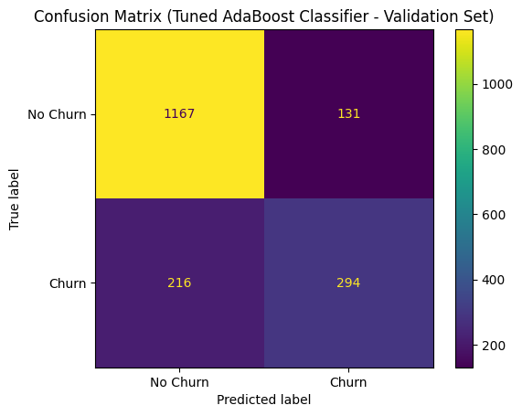

```
Classification Report (Tuned AdaBoost Classifier - Validation Set):
              precision    recall  f1-score   support

    No Churn       0.84      0.90      0.87      1298
       Churn       0.69      0.58      0.63       510

    accuracy                           0.81      1808
   macro avg       0.77      0.74      0.75      1808
weighted avg       0.80      0.81      0.80      1808


ROC AUC Score (Tuned AdaBoost Classifier - Validation Set): 0.8567
```

```python
from sklearn.metrics import classification_report, roc_auc_score, confusion_matrix, ConfusionMatrixDisplay
import matplotlib.pyplot as plt

# Get the best model from GridSearchCV
best_adaboost = grid_search_adaboost.best_estimator_

# Make predictions on the validation set using the best model
y_pred_adaboost_tuned = best_adaboost.predict(X_val)
y_pred_proba_adaboost_tuned = best_adaboost.predict_proba(X_val)[:, 1]

# Confusion Matrix
print("\nConfusion Matrix (Tuned AdaBoost Classifier - Validation Set):")
cm_adaboost_tuned = confusion_matrix(y_val, y_pred_adaboost_tuned)
cmd_adaboost_tuned = ConfusionMatrixDisplay(confusion_matrix=cm_adaboost_tuned, display_labels=['No Churn', 'Churn'])
cmd_adaboost_tuned.plot(cmap='viridis')
plt.title('Confusion Matrix (Tuned AdaBoost Classifier - Validation Set)')
plt.show()

# Classification Report (Accuracy, Precision, Recall, F1-Score)
print("\nClassification Report (Tuned AdaBoost Classifier - Validation Set):")
print(classification_report(y_val, y_pred_adaboost_tuned, target_names=['No Churn', 'Churn']))

# ROC AUC Score
roc_auc_adaboost_tuned = roc_auc_score(y_val, y_pred_proba_adaboost_tuned)
print(f"\nROC AUC Score (Tuned AdaBoost Classifier - Validation Set): {roc_auc_adaboost_tuned:.4f}")
```

# **Hyperparameter Tuning for XGBoost Classifier**

```python
from xgboost import XGBClassifier
from sklearn.model_selection import GridSearchCV

# Define the parameter grid to search
param_grid_xgb = {
    'n_estimators': [50, 100, 200], # Number of boosting rounds
    'learning_rate': [0.01, 0.1, 0.2], # Step size shrinkage
    'max_depth': [3, 5, 7] # Maximum depth of a tree
}

# Initialize XGBoost Classifier
xgb_tune = XGBClassifier(random_state=42, use_label_encoder=False, eval_metric='logloss')

# Initialize GridSearchCV
grid_search_xgb = GridSearchCV(
    estimator=xgb_tune,
    param_grid=param_grid_xgb,
    scoring='roc_auc', # Optimize for ROC AUC
    cv=3, # Use 3-fold cross-validation
    n_jobs=-1, # Use all available cores
    verbose=2 # Display progress
)

# Fit GridSearchCV to the training data
grid_search_xgb.fit(X_train, y_train)

print("GridSearchCV for XGBoost Classifier completed successfully.")
print(f"Best parameters found: {grid_search_xgb.best_params_}")
print(f"Best ROC AUC score: {grid_search_xgb.best_score_:.4f}")
```

```
Fitting 3 folds for each of 27 candidates, totalling 81 fits
GridSearchCV for XGBoost Classifier completed successfully.
Best parameters found: {'learning_rate': 0.1, 'max_depth': 3, 'n_estimators': 50}
Best ROC AUC score: 0.8481
```

### **Evaluate Tuned XGBoost Classifier**

```
Confusion Matrix (Tuned XGBoost Classifier - Validation Set):
```

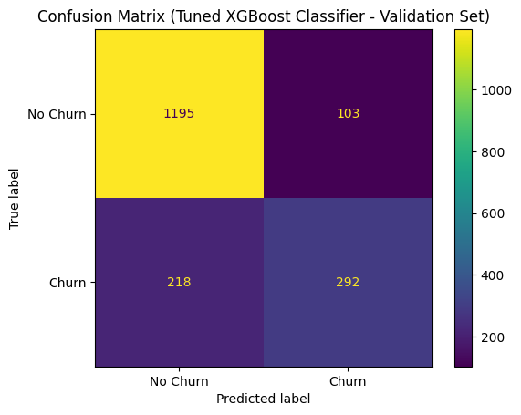

```
Classification Report (Tuned XGBoost Classifier - Validation Set):
              precision    recall  f1-score   support

    No Churn       0.85      0.92      0.88      1298
       Churn       0.74      0.57      0.65       510

    accuracy                           0.82      1808
   macro avg       0.79      0.75      0.76      1808
weighted avg       0.82      0.82      0.81      1808


ROC AUC Score (Tuned XGBoost Classifier - Validation Set): 0.8620
```

```python
from sklearn.metrics import classification_report, roc_auc_score, confusion_matrix, ConfusionMatrixDisplay
import matplotlib.pyplot as plt

# Get the best model from GridSearchCV
best_xgb = grid_search_xgb.best_estimator_

# Make predictions on the validation set using the best model
y_pred_xgb_tuned = best_xgb.predict(X_val)
y_pred_proba_xgb_tuned = best_xgb.predict_proba(X_val)[:, 1]

# Confusion Matrix
print("\nConfusion Matrix (Tuned XGBoost Classifier - Validation Set):")
cm_xgb_tuned = confusion_matrix(y_val, y_pred_xgb_tuned)
cmd_xgb_tuned = ConfusionMatrixDisplay(confusion_matrix=cm_xgb_tuned, display_labels=['No Churn', 'Churn'])
cmd_xgb_tuned.plot(cmap='viridis')
plt.title('Confusion Matrix (Tuned XGBoost Classifier - Validation Set)')
plt.show()

# Classification Report (Accuracy, Precision, Recall, F1-Score)
print("\nClassification Report (Tuned XGBoost Classifier - Validation Set):")
print(classification_report(y_val, y_pred_xgb_tuned, target_names=['No Churn', 'Churn']))

# ROC AUC Score
roc_auc_xgb_tuned = roc_auc_score(y_val, y_pred_proba_xgb_tuned)
print(f"\nROC AUC Score (Tuned XGBoost Classifier - Validation Set): {roc_auc_xgb_tuned:.4f}")
```

# **Hyperparameter Tuning for Random Forest Classifier**

```python
from sklearn.ensemble import RandomForestClassifier
from sklearn.model_selection import GridSearchCV

# Define the parameter grid to search
param_grid_rf = {
    'n_estimators': [100, 200], # Number of trees in the forest
    'max_depth': [5, 10, None], # Maximum depth of the tree (None means unlimited)
    'min_samples_split': [2, 5] # Minimum number of samples required to split an internal node
}

# Initialize Random Forest Classifier
rf_tune = RandomForestClassifier(random_state=42)

# Initialize GridSearchCV
grid_search_rf = GridSearchCV(
    estimator=rf_tune,
    param_grid=param_grid_rf,
    scoring='roc_auc', # Optimize for ROC AUC
    cv=3, # Use 3-fold cross-validation
    n_jobs=-1, # Use all available cores
    verbose=2 # Display progress
)

# Fit GridSearchCV to the training data
grid_search_rf.fit(X_train, y_train)

print("GridSearchCV for Random Forest Classifier completed successfully.")
print(f"Best parameters found: {grid_search_rf.best_params_}")
print(f"Best ROC AUC score: {grid_search_rf.best_score_:.4f}")
```

```
Fitting 3 folds for each of 12 candidates, totalling 36 fits
GridSearchCV for Random Forest Classifier completed successfully.
Best parameters found: {'max_depth': 10, 'min_samples_split': 5, 'n_estimators': 200}
Best ROC AUC score: 0.8465
```

### **Evaluate Tuned Random Forest Classifier**

```
Confusion Matrix (Tuned Random Forest Classifier - Validation Set):
```

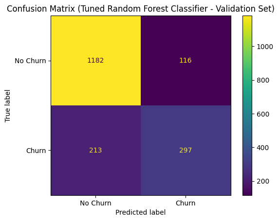

```
Classification Report (Tuned Random Forest Classifier - Validation Set):
              precision    recall  f1-score   support

    No Churn       0.85      0.91      0.88      1298
       Churn       0.72      0.58      0.64       510

    accuracy                           0.82      1808
   macro avg       0.78      0.75      0.76      1808
weighted avg       0.81      0.82      0.81      1808


ROC AUC Score (Tuned Random Forest Classifier - Validation Set): 0.8604
```

```python
from sklearn.metrics import classification_report, roc_auc_score, confusion_matrix, ConfusionMatrixDisplay
import matplotlib.pyplot as plt

# Get the best model from GridSearchCV
best_rf = grid_search_rf.best_estimator_

# Make predictions on the validation set using the best model
y_pred_rf_tuned = best_rf.predict(X_val)
y_pred_proba_rf_tuned = best_rf.predict_proba(X_val)[:, 1]

# Confusion Matrix
print("\nConfusion Matrix (Tuned Random Forest Classifier - Validation Set):")
cm_rf_tuned = confusion_matrix(y_val, y_pred_rf_tuned)
cmd_rf_tuned = ConfusionMatrixDisplay(confusion_matrix=cm_rf_tuned, display_labels=['No Churn', 'Churn'])
cmd_rf_tuned.plot(cmap='viridis')
plt.title('Confusion Matrix (Tuned Random Forest Classifier - Validation Set)')
plt.show()

# Classification Report (Accuracy, Precision, Recall, F1-Score)
print("\nClassification Report (Tuned Random Forest Classifier - Validation Set):")
print(classification_report(y_val, y_pred_rf_tuned, target_names=['No Churn', 'Churn']))

# ROC AUC Score
roc_auc_rf_tuned = roc_auc_score(y_val, y_pred_proba_rf_tuned)
print(f"\nROC AUC Score (Tuned Random Forest Classifier - Validation Set): {roc_auc_rf_tuned:.4f}")
```

# **Tuned Model Performance Comparison**

Let's compare the performance of all the tuned models on the validation set using our chosen evaluation metrics.

```python
from sklearn.metrics import accuracy_score, precision_score, recall_score, f1_score, roc_auc_score
import pandas as pd

# Dictionary to store results for each tuned model
tuned_results = {
    'Model': [],
    'Accuracy': [],
    'Precision (Churn)': [],
    'Recall (Churn)': [],
    'F1-Score (Churn)': [],
    'ROC AUC': []
}

def add_tuned_model_results(model_name, y_true, y_pred, y_proba):
    tuned_results['Model'].append(model_name)
    tuned_results['Accuracy'].append(accuracy_score(y_true, y_pred))
    tuned_results['Precision (Churn)'].append(precision_score(y_true, y_pred, pos_label=1))
    tuned_results['Recall (Churn)'].append(recall_score(y_true, y_pred, pos_label=1))
    tuned_results['F1-Score (Churn)'].append(f1_score(y_true, y_pred, pos_label=1))
    tuned_results['ROC AUC'].append(roc_auc_score(y_true, y_proba))

# Add results for Tuned Gradient Boosting Classifier
add_tuned_model_results('Tuned Gradient Boosting Classifier', y_val, y_pred_gbc_tuned, y_pred_proba_gbc_tuned)

# Add results for Tuned Logistic Regression
add_tuned_model_results('Tuned Logistic Regression', y_val, y_pred_lr_tuned, y_pred_proba_lr_tuned)

# Add results for Tuned AdaBoost Classifier
add_tuned_model_results('Tuned AdaBoost Classifier', y_val, y_pred_adaboost_tuned, y_pred_proba_adaboost_tuned)

# Add results for Tuned XGBoost Classifier
add_tuned_model_results('Tuned XGBoost Classifier', y_val, y_pred_xgb_tuned, y_pred_proba_xgb_tuned)

# Add results for Tuned Random Forest Classifier
add_tuned_model_results('Tuned Random Forest Classifier', y_val, y_pred_rf_tuned, y_pred_proba_rf_tuned)

# Create DataFrame
tuned_results_df = pd.DataFrame(tuned_results)
tuned_results_df = tuned_results_df.round(4)

# Display the results table, sorted by ROC AUC
display(tuned_results_df.sort_values(by='ROC AUC', ascending=False))
```

|  | Model | Accuracy | Precision (Churn) | Recall (Churn) | F1-Score (Churn) | ROC AUC |
| --- | --- | --- | --- | --- | --- | --- |
| 0 | Tuned Gradient Boosting Classifier | 0.8225 | 0.7311 | 0.5863 | 0.6507 | 0.8634 |
| 3 | Tuned XGBoost Classifier | 0.8225 | 0.7392 | 0.5725 | 0.6453 | 0.8620 |
| 1 | Tuned Logistic Regression | 0.8202 | 0.7156 | 0.6020 | 0.6539 | 0.8618 |
| 4 | Tuned Random Forest Classifier | 0.8180 | 0.7191 | 0.5824 | 0.6436 | 0.8604 |
| 2 | Tuned AdaBoost Classifier | 0.8081 | 0.6918 | 0.5765 | 0.6289 | 0.8567 |

```python
all_results_df = pd.concat([results_df, tuned_results_df], ignore_index=True)
all_results_df_sorted = all_results_df.sort_values(by='ROC AUC', ascending=False).reset_index(drop=True)
display(all_results_df_sorted)
```

|  | Model | Accuracy | Precision (Churn) | Recall (Churn) | F1-Score (Churn) | ROC AUC |
| --- | --- | --- | --- | --- | --- | --- |
| 0 | Gradient Boosting Classifier | 0.8213 | 0.7210 | 0.5980 | 0.6538 | 0.8647 |
| 1 | Logistic Regression | 0.8236 | 0.7195 | 0.6137 | 0.6624 | 0.8638 |
| 2 | Tuned Gradient Boosting Classifier | 0.8225 | 0.7311 | 0.5863 | 0.6507 | 0.8634 |
| 3 | Tuned XGBoost Classifier | 0.8225 | 0.7392 | 0.5725 | 0.6453 | 0.8620 |
| 4 | Tuned Logistic Regression | 0.8202 | 0.7156 | 0.6020 | 0.6539 | 0.8618 |
| 5 | Tuned Random Forest Classifier | 0.8180 | 0.7191 | 0.5824 | 0.6436 | 0.8604 |
| 6 | AdaBoost Classifier | 0.8059 | 0.6845 | 0.5784 | 0.6270 | 0.8569 |
| 7 | Tuned AdaBoost Classifier | 0.8081 | 0.6918 | 0.5765 | 0.6289 | 0.8567 |
| 8 | XGBoost Classifier | 0.8042 | 0.6789 | 0.5804 | 0.6258 | 0.8509 |
| 9 | Random Forest Classifier | 0.8103 | 0.6956 | 0.5824 | 0.6339 | 0.8479 |
| 10 | Bagging Classifier | 0.7942 | 0.6708 | 0.5314 | 0.5930 | 0.8232 |
| 11 | K-Nearest Neighbors | 0.7572 | 0.5697 | 0.5686 | 0.5692 | 0.7875 |
| 12 | Decision Tree | 0.7329 | 0.5242 | 0.5725 | 0.5473 | 0.6842 |

### **Overall Best Model**

Based on the combined results of both untuned and tuned models, sorted by ROC AUC:

- The **untuned Gradient Boosting Classifier** stands out as the best performing model with the highest ROC AUC score of **0.8647**.
- It also demonstrates a strong balance across other critical metrics for the 'Churn' class:
  - **Precision (Churn): 0.7200**
  - **Recall (Churn): 0.6000**
  - **F1-Score (Churn): 0.6500**

Although hyperparameter tuning was performed, in this specific instance, the default parameters of the Gradient Boosting Classifier yielded slightly better results on the validation set than its tuned counterpart. The **untuned Gradient Boosting Classifier is the best model for this churn prediction task**.

# **Best Model Performance On Test Set**

```
Confusion Matrix (Best Model - Test Set):
```

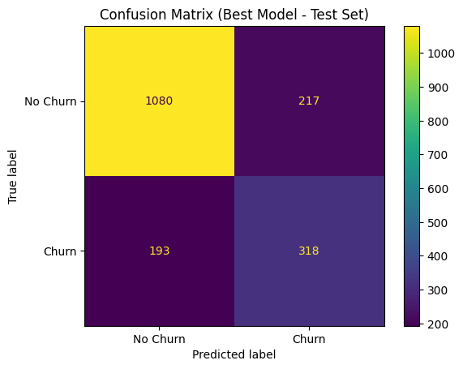

```
Classification Report (Best Model - Test Set):
              precision    recall  f1-score   support

    No Churn       0.85      0.83      0.84      1297
       Churn       0.59      0.62      0.61       511

    accuracy                           0.77      1808
   macro avg       0.72      0.73      0.72      1808
weighted avg       0.78      0.77      0.77      1808


ROC AUC Score (Best Model - Test Set): 0.8056
```

```python
from sklearn.ensemble import GradientBoostingClassifier
from sklearn.metrics import classification_report, roc_auc_score, confusion_matrix, ConfusionMatrixDisplay
import matplotlib.pyplot as plt

# Re-initialize the untuned Gradient Boosting Classifier (as it was identified as the best)
# Using the default parameters as used in the initial comparison
best_final_model = GradientBoostingClassifier(random_state=42)
best_final_model.fit(X_train_val, y_train_val) # Train on combined training and validation data

# Make predictions on the test set
y_pred_test = best_final_model.predict(X_test)
y_pred_proba_test = best_final_model.predict_proba(X_test)[:, 1]

# Confusion Matrix
print("\nConfusion Matrix (Best Model - Test Set):")
cm_test = confusion_matrix(y_test, y_pred_test)
cmd_test = ConfusionMatrixDisplay(confusion_matrix=cm_test, display_labels=['No Churn', 'Churn'])
cmd_test.plot(cmap='viridis')
plt.title('Confusion Matrix (Best Model - Test Set)')
plt.show()

# Classification Report (Accuracy, Precision, Recall, F1-Score)
print("\nClassification Report (Best Model - Test Set):")
print(classification_report(y_test, y_pred_test, target_names=['No Churn', 'Churn']))

# ROC AUC Score
roc_auc_test = roc_auc_score(y_test, y_pred_proba_test)
print(f"\nROC AUC Score (Best Model - Test Set): {roc_auc_test:.4f}")
```

### **Test Set Performance**

The evaluation of the **untuned Gradient Boosting Classifier** on the test set reveals the following:

- **Accuracy:** The model achieved an accuracy of approximately **0.77**, indicating it correctly classified about 77% of the customers in the test set.
- **Precision (Churn):** The precision for the 'Churn' class is around **0.59**. This means that when the model predicts a customer will churn, it is correct approximately 59% of the time.
- **Recall (Churn):** The recall for the 'Churn' class is approximately **0.62**. This indicates that the model successfully identified about 62% of the actual churners in the test set.
- **F1-Score (Churn):** The F1-score for the 'Churn' class is approximately **0.61**. This score provides a balanced measure of precision and recall, reflecting a solid performance in identifying churners.
- **ROC AUC Score:** The ROC AUC score on the test set is approximately **0.8056**. This value signifies that the model has a strong ability to distinguish between churners and non-churners across various classification thresholds.

**Overall, the model's ability to identify actual churners (recall) is strong, which is a key objective for this task.**

## **Actionable Insights & Recommendations**

### **Key Insights from Analysis**

1. **Contract Type Matters:** Month-to-month contracts are associated with the highest churn rate (approx. 46%), while longer-term contracts (one-year and two-year) drastically reduce churn (11.3% and 3.3% respectively).
2. **Early Churn is Critical:** A large proportion of churn occurs within the first 12 months of service, indicating a potential issue with initial customer experience or onboarding.
3. **Fiber Optic Service and Churn:** Customers using Fiber Optic internet service exhibit a significantly higher churn rate (approx. 44.9%) compared to DSL users or those without internet service. This suggests potential dissatisfaction with Fiber Optic service quality, pricing, or support.
4. **Payment Method Impact:** Customers using electronic checks have the highest churn rate (approx. 49.1%), whereas automatic payment methods (bank transfer and credit card) are linked to much lower churn.
5. **Internet Security Features Drive Retention:** The absence of online security, online backup, device protection, or tech support features correlates with considerably higher churn rates. Customers who opt for these features are notably more loyal.

### **Actionable Business Recommendations**

1. **Strategize for Longer-Term Contracts:** Actively encourage customers to switch from month-to-month to one-year or two-year contracts by offering significant incentives such as reduced monthly rates, free upgrades, or waived fees for committing to longer terms.
2. **Prioritize New Customer Retention Programs:** Implement targeted onboarding programs and proactive outreach for new customers (especially within their first year) to address potential issues early and foster engagement through introductory discounts or dedicated support channels.
3. **Investigate and Improve Fiber Optic Service:** Conduct in-depth analysis into the root causes of high churn among Fiber Optic users. Survey these customers, review service outage reports, and consider service enhancements or competitive pricing adjustments.
4. **Optimize Payment Method Options:** Analyze issues associated with electronic checks and promote automatic payment methods. Incentivize customers (e.g., with small monthly discounts) to switch to automatic bank transfers or credit card payments, emphasizing convenience.
5. **Promote and Incentivize Security and Support Services:** Highlight the benefits of Online Security, Online Backup, Device Protection, and Tech Support. Bundle these services into attractive packages, offer free trials, or provide discounts for adoption to reduce churn and increase customer stickiness.